# Grays Harbor Recreational Crab Harvest Estimate

Pooled CPUE Model - 2024-25 Season Results Report

Washington Department of Fish and Wildlife

2026-09-03

> **How to read this report.** This is the results report for one seasonal harvest estimate from the pooled CPUE model. Code is hidden by default; use the **Code** buttons (or *Code > Show All Code* at the top right) to reveal any step. Each section states what it does, shows the notable tables and figures, and, for the diagnostic sections, notes what a healthy run should look like. The headline number is the port total in the Results section; always read it together with the convergence and PE-vs-BSS sections, which say how much to trust it.

## 1. Setup and configuration

Loads packages, sources the helper functions in `03_R_functions/`, applies the run configuration from `run_config.R`, and defines the two sub-seasons (pot-closure and all-gear). Every user-selectable toggle for this run lives in `run_config.R`.

```r
###############################################################################
# Crab Creel Estimation - Westport / Grays Harbor  |  Pooled CPUE Model
# 2024-25 Season  |  Pipeline code v7.9 (2026-07-12)
#
# Estimates total recreational Dungeness crab harvest at Westport / Grays Harbor
# from a single pooled CPUE process shared across gear types. Three population
# components are estimated independently and summed to the port total:
#   1. Shore crabbers (dock + jetty + beach)   BSS + PE
#   2. Private boat crabbers                    BSS + PE
#   3. Commercial/charter boats                 census/tally
# Two gear-regime sub-seasons: pot closure (Sep 16 - Nov 30, non-pot gear only) and
# all-gear (Dec 1 - Sep 15, pots allowed). "Pot closure" was formerly labeled
# "ring-net only"; non-pot gear other than ring nets is also legal, so the name was
# a misnomer. The internal key stays "ring_net_only" for output-filename continuity.
#
# CURRENT STATE (v7.9): both fitted components run on the gear-DEPLOYMENT effort
# unit (h = number_of_gear, L = tau), via the shared 03_R_functions/bss_effort_spec.R.
# Helper functions live in 03_R_functions/ (sourced wholesale in the setup chunk),
# and every user-selectable toggle lives in run_config.R (the single file you edit);
# this .Rmd's params block holds only model-internal tuning (sampler settings, gate
# and AR-selector thresholds).
#
# KEY FEATURES: adaptive AR(1) temporal resolution; B1_C weekend CPUE effect;
# L_effective day length estimated with uncertainty from I/E; data-driven R_G prior;
# gear-deployment effort scale (R_G_boat / tau_boat, tau_shore); scale-aware
# convergence gate; expected + predictive catch in the generated quantities.
#
# FULL CHANGE LOG (every version, newest first, with working notes):
#   07_documentation/BSS-GH-pooled-CPUE-model-development-history.md
# METHOD REFERENCE (the published method of record):
#   07_documentation/BSS-GH-pooled-CPUE-model-documentation.md
###############################################################################

# ===========================================================================
# 0. SETUP
# ===========================================================================

load.lib <- c("tidyverse","lubridate","suncalc","gt","patchwork","rstan","here","readxl")
install.lib <- load.lib[!load.lib %in% installed.packages()]
for(lib in install.lib) install.packages(lib, dependencies=TRUE)
sapply(load.lib, require, character=TRUE)
rstan_options(auto_write = TRUE)
purrr::walk(list.files(here("03_R_functions"), full.names = TRUE), source)

run_date <- format(Sys.Date(), "%Y%m%d")
# Unique per-run subfolder so same-day runs never overwrite each other.
# run_config$run_tag (set in run_config.R, or by run_rg_sweep.R) names the folder,
# e.g. pooled-CPUE-run5; blank falls back to a HHMMSS timestamp. The `knit:` block
# above stashes that timestamp in options(crab_run_tag=) so a standalone RStudio
# knit writes its HTML and this driver's CSVs into the SAME folder.
.run_tag <- if (exists("run_config") && is.list(run_config) &&
                !is.null(run_config$run_tag) && nzchar(run_config$run_tag)) {
  run_config$run_tag
} else getOption("crab_run_tag", format(Sys.time(), "%H%M%S"))
output_dir <- here("05_output", run_date, paste0("pooled-CPUE-", .run_tag))
if (!dir.exists(output_dir)) dir.create(output_dir, recursive = TRUE)

# timer_start() / timer_stop() and their timing state now live in
# 03_R_functions/bss_timers.R (auto-sourced). Read collected timings with
# bss_timer_log(). Extracted; behavior unchanged.

run_start_time <- Sys.time()

# ===========================================================================
# 0.1 PARAMETERS
# ===========================================================================

params <- list(
  # NOTE: every user-selectable toggle (season window, structural dates, catch
  # groups, day-typing, effort unit, incomplete-trip filter, I/E settings,
  # holidays, and the model-behavior levers such as collapse_mu_hier) now lives in
  # run_config.R, the single source of truth, and is applied as an override below.
  # This list holds ONLY this model's internal tuning: the Stan model file, the
  # per-fit sampler settings, the convergence-gate thresholds, and the adaptive
  # AR-selector thresholds. These rarely change and legitimately differ from the
  # gear-resolved model, so they stay with the model rather than in run_config.

  # --- Stan model file ---
  bss_model_file    = "crab_bss_pooled.stan",

  # --- Shared reader behavior (merged fetch_crab_data, 2026-08-01) ---
  # TRUE = the historical pooled reader: drop private_boat interviews with no
  # positive gear_time_total. (The gear-resolved driver sets FALSE.)
  boat_require_gear_time = TRUE,

  # --- BSS sampler defaults ---
  bss_adapt_delta   = 0.9,

  # --- BSS convergence tuning (extra iterations for longer sub-seasons / daily AR) ---
  bss_iter_default          = 3000,
  bss_warmup_default        = 1500,
  bss_max_treedepth_default = 10,
  bss_iter_shore_allgear    = 5000,
  bss_warmup_shore_allgear  = 2500,

  # Per-fit treedepth / adapt_delta overrides (v6.1, ported from gear-resolved
  # v5.2). The shore all-gear daily-AR posterior is the densest geometry and
  # saturated max_treedepth=10 on 91.6% of iterations in the 2026-04-08 run;
  # ring-net fits are data-sparse and benefit from tighter adaptation. Any fit
  # without an override uses the *_default values.
  bss_treedepth_shore_allgear = 14,
  bss_delta_shore_allgear     = 0.95,
  bss_treedepth_ringnet       = 12,
  bss_delta_ringnet           = 0.95,

  # v6.2: boat all-gear sampler tuning. The boat all-gear fit failed in the
  # 2026-04-08 run (5998 divergences, R-hat 1.074, n_eff 76) under defaults.
  # treedepth_pct was 0, so divergences came from step size: adapt_delta is
  # raised to 0.99 (primary lever) and max_treedepth to 13 (buffer), with more
  # iterations to give n_eff a chance to clear 400.
  bss_iter_boat_allgear       = 5000,
  bss_warmup_boat_allgear     = 2500,
  bss_treedepth_boat_allgear  = 13,
  bss_delta_boat_allgear      = 0.99,
```

```r
  # bss_min_interviews MOVED to run_config.R (improvement 6, 2026-08-25). It lived here,
  # in params_model, which is merged ON TOP of run_config -- so a value set in run_config
  # was silently overridden by this one. Both the pre-filter floor
  # (bss_min_interviews) and the new post-filter floor (bss_min_interviews_fitted) are
  # now single-sourced from run_config.R.

  # --- B1.8: SCALE-AWARE convergence gate thresholds --------------------------
  # The gate rejects a BSS fit whose divergent transitions have BIASED the
  # reported totals, while accepting a fit whose divergences are diffuse and
  # harmless (Betancourt 2017). It measures the divergent draws' impact on each
  # reported TOTAL in units of that total's posterior SD (scale-invariant):
  #   impact = |median(all_draws) - median(bulk_draws)| / sd(all_draws)
  # A fit passes when max(impact_C, impact_E) is below max_divergence_total_impact_sd,
  # with a hard divergent-FRACTION backstop (max_divergence_fraction). See the
  # model documentation and development history for the full B1.8 rationale.
  max_divergence_total_impact_sd = 0.10,
  # P7 (2026-07-12): tightened from 0.15 to 0.05. The scale-aware impact test above
  # (max_divergence_total_impact_sd) is the primary gate; this fraction is only a hard
  # backstop, and 0.15 was too loose to defend for a publication method (a fit at ~14%
  # divergences would have passed as BSS). 0.05 matches the gear-resolved model. The
  # 2026-07-11 pooled fits (0.54%, 2.23%, 2.5% divergences) are all under 5%, so this
  # changes no current gating decision; divergences indicate biased HMC exploration
  # (Betancourt 2017), so the backstop belongs near 5%.
  max_divergence_fraction        = 0.05,

  # --- DEPRECATED gate parameters (retained for reference; no longer gating) ---
  # Superseded by the scale-aware gate above. The level-normalized distortion is
  # still COMPUTED and reported in convergence_report.csv (distortion_C /
  # distortion_E) for continuity, but neither value participates in pass/fail.
  max_divergences = 5,
  max_divergence_distortion = 0.02,

  # --- Adaptive AR temporal-resolution thresholds -----------------------------
  # The model selects the finest AR resolution the data can support:
  #   daily:   effort obs on >= ar_daily_min_coverage of days AND >= ar_daily_min_obs
  #   weekly:  >= ar_weekly_min_per_week effort obs per week on average
  #   monthly: fallback for sparse data
  ar_daily_min_coverage  = 0.25,
  ar_daily_min_obs       = 20,
  ar_weekly_min_per_week = 1.5,

  # v6.5 (B1): per-population cap on AR resolution. The map now lives in run_config.R
  # (ar_max_resolution$pooled) so both models' caps sit in one place; this model's cap
  # is selected from it just after the merge below (P5, 2026-07-12). The boat
  # (trailer-count) effort series is too weakly informative for daily AR, so the boat
  # is capped at weekly; a population absent from the map defaults to "daily" (no cap).

  # --- I/E diagnostics ---
  ie_use_all_dates_for_diagnostics = TRUE
)

# --- Run-level config from run_config.R (single source of truth) --------------
# run_config.R owns every user-selectable toggle (season window, structural dates,
# catch groups, day-typing, effort unit, filters, I/E settings, holidays, the AR
# resolution map, and the model-behavior toggles). When launched via run_estimation.R
# the orchestrator has already defined `run_config`; when this .Rmd is knit standalone
# the guard below sources run_config.R so the same toggles are used either way.
if (!exists("run_config")) source(here::here("run_config.R"))
# P5 (2026-07-12): run_config is the BASE parameter set; this model's internal tuning
# (defined above) is layered on top. The two key sets are disjoint, so the merge order
# carries intent only (run_config is the base, the model updates it with its specifics).
params <- modifyList(run_config, params)
# 2026-08-30: the ONE sanctioned way for run_config to reach a sampler setting, applied
# AFTER the merge because params_model wins it (03_R_functions/bss_sampler_override.R).
# Unset in production, so this is a no-op on a normal run; it errors loudly on a
# non-sampler key rather than silently dropping it.
params <- bss_apply_sampler_override(params, model_label = "pooled")
# Select this model's AR-resolution cap from the shared per-model map in run_config.
params$ar_max_resolution <- run_config$ar_max_resolution$pooled

# Crabbing holidays now live in an editable workbook (04_input_files/crabbing_holidays.xlsx),
# read here via 03_R_functions/read_crabbing_holidays.R and filtered to season_filter, so the
# season update is a spreadsheet edit rather than a code edit. Populate params$crabbing_holiday_dates
# ONCE here; every downstream consumer (classify_day_type, prep_days_crab, estimate_comm_charter)
# reads it from params unchanged. Kept as a bare object too so inline references still resolve.
params$crabbing_holiday_dates <- read_crabbing_holidays(params)
crabbing_holiday_dates <- params$crabbing_holiday_dates


catch_groups <- if(params$estimate_red_rock) {
  c("Dungeness_Kept", "Red_Rock_Kept")
} else {
  "Dungeness_Kept"
}

# Sub-seasons split by the pot-closure window (03_R_functions/build_subseasons.R).
# The pot closure is when pots are not legal (non-pot gear only); its window is set
# explicitly in run_config (pot_closure_start / pot_closure_end). For the current
# config (closure at the season start) this returns the historical two sub-seasons
# with unchanged internal names ("ring_net_only" is the pot-closure key, kept for
# output-filename continuity; display_name is "Pot closure"), so keys and filenames
# do not change. A mid-season closure adds pre/post all-gear periods automatically.
# Model logic keys off ss$gear_regime ("pot_closure" | "all_gear"), never ss$name.
subseasons <- build_subseasons(params)
for (ss in subseasons) {
  cat(sprintf("Sub-season: %-26s %s to %s (%d days)\n",
              paste0(ss$display_name, " [", ss$name, "]"),
              ss$start, ss$end, as.integer(ss$end - ss$start + 1)))
}
cat(sprintf("Catch groups: %s\n", paste(catch_groups, collapse = ", ")))
```

```r
# Sub-season aggregation is now GENERAL (2026-07-13): the PE port summary, the catch-by-
# mode table, and the final harvest table sum over whatever sub-seasons build_subseasons
# produced (via pe_pop_sum / pe_port_total below), rather than the hardcoded historical
# pair. A mid-season pot closure (which adds all_gear_pre / all_gear_post keys) is
# therefore handled end-to-end. That general path has NOT yet been validated against a
# fitted run, so emit a loud note when the sub-season set departs from the historical
# pair; verify the port total against the per-component PE table before citing such a run.
ss_name_set <- vapply(subseasons, function(z) z$name, character(1))
if (!setequal(ss_name_set, c("ring_net_only", "all_gear"))) {
  cat(sprintf(paste0(
    "\n*** NOTE: non-historical sub-season set {%s}. The report aggregation sums over all ",
    "sub-seasons per population, but this configuration has not been validated against a ",
    "fitted run; verify the port total against the per-component PE table before citing. ***\n"),
    paste(ss_name_set, collapse = ", ")))
}

# --- Generalized PE aggregation over the sub-season set (build_subseasons) -----------
# Sum a PE field over all sub-seasons of a population so the port total, the by-mode
# table, and the final-table PE rows follow build_subseasons instead of a fixed 5-row
# layout. These close over the run globals `pe_all` (populated by the PE loop) and
# `subseasons`; they are only called after the PE loop, so pe_all exists by call time.
# pe_all keys are "<population>_<subseason-name>"; a missing key or field contributes 0.
pe_field   <- function(key, field) pe_all[[key]][[field]] %||% 0
pe_pop_sum <- function(pop, field)
  sum(vapply(subseasons, function(ss) pe_field(paste0(pop, "_", ss$name), field), numeric(1)), na.rm = TRUE)
pe_port_total <- function(field)  # na.rm matches the baseline sum([1:5], na.rm=TRUE):
  sum(pe_pop_sum("shore", field), pe_pop_sum("private_boat", field),
      pe_field("comm_charter", field), na.rm = TRUE)


# ===========================================================================
# 0.2 STANDALONE DAY-TYPE CLASSIFIER
#
# Assigns day_type to ANY date, independent of the estimation calendar.
# Use this for diagnostic plots that may show data outside the estimation
# period (e.g., effort data collected year-round but est_date_end is Jan 31).
# ===========================================================================

# classify_day_type() now lives in 03_R_functions/classify_day_type.R
# (auto-sourced). Signature is now (dates, params); it reads weekends/holidays
# from params. Behavior unchanged.


# ===========================================================================
# 1. DATA INGESTION
# ===========================================================================

# fetch_crab_data() now lives in 03_R_functions/fetch_crab_data.R
# (auto-sourced). Extracted verbatim; behavior unchanged.


# ===========================================================================
# 1.5 INGRESS/EGRESS DATA
# ===========================================================================

# fetch_ie_data() now lives in 03_R_functions/bss_day_length.R, shared with the
# gear-resolved driver so the two cannot drift. It is auto-sourced by the
# purrr::walk over 03_R_functions/ near the top of this file. Function body
# moved verbatim; behavior unchanged.


# ===========================================================================
# 1.6 L_EFFECTIVE MODEL - Regression with uncertainty propagation
#
# Fits a
# regression of log(L_effective) on day-of-year (quadratic) and day type.
# This captures the seasonal gradient WITHIN sub-seasons and provides
# per-day prediction uncertainty for propagation into the Stan model.
#
# Returns: list with
#   $predict_fn: function(event_date, day_type) -> tibble(L_mu, L_sigma)
#   $model: the fitted lm object
#   $detail: per-I/E-day data
#   $summary: model coefficients and fit statistics
# ===========================================================================

# estimate_L_effective() now lives in 03_R_functions/bss_day_length.R, shared
# with the gear-resolved driver so the two cannot drift. It is auto-sourced by
# the purrr::walk over 03_R_functions/ near the top of this file. Function body
# moved verbatim; behavior unchanged.


# ===========================================================================
# 2. PREP DAYS - Build calendar with L_mu and L_sigma per day
#
# Stores both L_mu (predicted median) and L_prior_sigma
# lookup value, store both L_mu (predicted median) and L_prior_sigma
# (prediction uncertainty on log scale) for each day. These feed into
# the Stan model where L becomes a parameter.
# ===========================================================================

# prep_days_crab() now lives in 03_R_functions/prep_days_crab.R (shared,
# auto-sourced). Signature is now (date_begin, date_end, params, L_eff_model);
# it derives weekends/holidays/period_pe/sections from params. Behavior unchanged.


# ===========================================================================
# 3. SUMMARIZE DATA - Filter to population x sub-season
# ===========================================================================

# prep_population_summary() now lives in
# 03_R_functions/prep_population_summary.R (shared, auto-sourced). catch_groups is
# derived from params inside. Behavior unchanged.


# ===========================================================================
# 4. PE METHOD - (unchanged from v1)
# ===========================================================================

# run_pe_pooled() now lives in 03_R_functions/run_pe_pooled.R (auto-sourced).
# catch_groups is derived from params; the shore branch now flows through
# bss_effort_spec() so shore PE matches the shore BSS unit (2026-07-11 fix).


# ===========================================================================
# 5. BSS PREP - Build Stan data list for crab_bss_pooled.stan
#
# ADAPTIVE AR RESOLUTION: Selects daily, weekly, or monthly AR based on
# effort data density. Dense data → daily AR for smooth interpolation.
# Sparse data → coarser resolution to avoid poorly-identified AR dynamics.
#
# Also includes: data-driven R_G prior, L_effective as parameter (shore),
# informative R_G_boat prior, tightened Cauchy scales, no interview cap.
# ===========================================================================
```

```r
# prep_bss_crab_pooled() now lives in 03_R_functions/prep_bss_crab_pooled.R
# (auto-sourced). Extracted verbatim (renamed); behavior unchanged.


# ===========================================================================
# 6. COMMERCIAL/CHARTER CENSUS (unchanged from v1)
# ===========================================================================

# estimate_comm_charter() now lives in 03_R_functions/estimate_comm_charter.R
# (shared, auto-sourced). crabbing_holiday_dates read from params. Behavior unchanged.


# ===========================================================================
# 7. RUN EVERYTHING
# ===========================================================================
```

## 2. Data ingestion

Reads the season’s effort counts, crabber interviews, commercial tally, and ingress/egress (I/E) surveys, and classifies each interview into shore, private-boat, or commercial/charter.

```r
# ---- 7.0 LOAD DATA ----
timer_start("1_load_data")
cat("\n", strrep("=",60), "\n LOADING DATA\n", strrep("=",60), "\n")
dwg <- fetch_crab_data(params)
ie_data <- fetch_ie_data(params)
params$crab_fraction_rows <- attr(ie_data, "crab_fraction_rows")  # Phase 2b/3: crab-fraction classification (PE + BSS)

# --- Phase 0: OSP Westport boat-count ingest + overlap calibration (diagnostic only) ---
# fetch_osp_boat_counts() and diagnose_osp_trailer_overlap() live in 03_R_functions/
# (auto-sourced). The diagnostic writes osp_trailer_overlap_calibration.csv,
# osp_trailer_overlap_pairs.csv, osp_coverage_audit.csv and osp_trailer_overlap.png to
# output_dir. osp_boat is the per-day OSP series (boat_effort schema) that Phase 1
# consumes as a second boat effort stream. Guarded so a missing file cannot break a run.
osp_boat <- tryCatch(fetch_osp_boat_counts(params),
                     error = function(e) { cat("  OSP ingest skipped:", conditionMessage(e), "\n"); NULL })
osp_overlap <- tryCatch(diagnose_osp_trailer_overlap(osp_boat, params, output_dir = output_dir),
                        error = function(e) { cat("  OSP overlap diagnostic skipped:", conditionMessage(e), "\n"); NULL })
# improvement 8: OSP crab-ONLY counts (a LOWER bound on the crabbing fraction f, because
# OSP labels combo trips by the non-crab fishery). Lifted here so both the PE and the BSS
# read the same rows from one file read. Empty until the crab-only column exists, in which
# case every f feature is inert and f behaves exactly as it does today.
params$osp_crab_rows <- attr(osp_boat, "osp_crab_rows")
if (!is.null(params$osp_crab_rows) && nrow(params$osp_crab_rows) > 0)
  cat(sprintf("  OSP crab-only rows lifted for the f lower bound: %d day(s).\n",
              nrow(params$osp_crab_rows)))

# --- Fit L_effective regression ---
L_eff_model <- NULL
if(isTRUE(params$use_ie_day_length) && nrow(ie_data) > 0) {
  L_eff_model <- estimate_L_effective(ie_data, params$pot_open_date, params)
  if(!is.null(L_eff_model)) {
    # Save regression diagnostics
    if(!is.null(L_eff_model$detail)) {
      write.csv(L_eff_model$detail,
                file.path(output_dir, "L_effective_ie_detail.csv"), row.names = FALSE)
    }
  }
}
timer_stop("1_load_data")
```

## 3. Input diagnostics: effort, CPUE, and day length

Diagnostic views of the raw inputs before any modeling: sampled effort over the season by day type, interview CPUE over time, and the effective day length derived from the I/E surveys. Use these to spot data gaps or anomalies (for example a run of unsampled weekends, or an implausible CPUE spike).

```r
# ---- 7.1 DIAGNOSTIC PLOTS ----
timer_start("2_diagnostic_plots")
cat("\n", strrep("=",60), "\n DIAGNOSTIC PLOTS\n", strrep("=",60), "\n")

days_full <- prep_days_crab(params$est_date_start, params$est_date_end,
                            params, L_eff_model = L_eff_model)

# Plot 1: Shore gear count timeseries
p_shore_effort <- dwg$shore_effort |>
  group_by(event_date) |>
  summarise(total_gear = sum(count_quantity), n_counts = n(), .groups = "drop") |>
  mutate(day_type = classify_day_type(event_date, params)) |>
  ggplot(aes(x = event_date, y = total_gear, color = day_type, size = n_counts)) +
  geom_point(alpha = 0.5) +
  pot_closure_markers(params, labels = TRUE) +
  scale_size_continuous(range = c(1,3), breaks = 1:3, name = "Counts/day") +
  labs(title = "Shore: Daily Gear Count (Docks F20 + F17-21)",
       x = "Date", y = "Total gear count", color = "Day type") +
  theme_bw()
ggsave(file.path(output_dir, "plot_shore_effort_timeseries.png"), p_shore_effort, width = 10, height = 6)

# Plot 2: Boat trailer count timeseries
p_boat_effort <- dwg$boat_effort |>
  group_by(event_date) |>
  summarise(total_trailers = sum(count_quantity), n_counts = n(), .groups = "drop") |>
  mutate(day_type = classify_day_type(event_date, params)) |>
  ggplot(aes(x = event_date, y = total_trailers, color = day_type)) +
  geom_point(alpha = 0.5) +
  pot_closure_markers(params, labels = FALSE) +
  labs(title = "Private Boat: Daily Trailer Count", x = "Date", y = "Trailers", color = "Day type") +
  theme_bw()
ggsave(file.path(output_dir, "plot_boat_effort_timeseries.png"), p_boat_effort, width = 10, height = 6)

# Plot 3: CPUE by population
cpue_data <- dwg$interview |>
  filter(fishing_time_total > 0, dungeness_kept >= 0) |>
  mutate(cpue = dungeness_kept / fishing_time_total) |>
  group_by(event_date, population) |>
  summarise(mean_cpue = mean(cpue), n_int = n(), .groups = "drop") |>
  mutate(day_type = classify_day_type(event_date, params)) |>
  filter(population %in% c("shore", "private_boat"))

p_cpue <- cpue_data |>
  ggplot(aes(x = event_date, y = mean_cpue, color = day_type)) +
  geom_point(alpha = 0.4, size = 1.5) +
  geom_smooth(method = "loess", span = 0.3, se = TRUE, color = "grey30") +
  pot_closure_markers(params, labels = FALSE) +
  facet_wrap(~population, ncol = 1, scales = "free_y") +
  labs(title = "Dungeness CPUE by Population", x = "Date", y = "Mean CPUE", color = "Day type") +
  theme_bw()
ggsave(file.path(output_dir, "plot_cpue_timeseries.png"), p_cpue, width = 10, height = 8)

# Plot 4: Gear counts by month and day type (boxplot)
p_effort_month <- dwg$shore_effort |>
  group_by(event_date) |>
  summarise(total_gear = sum(count_quantity), .groups = "drop") |>
  mutate(day_type = classify_day_type(event_date, params),
         month_label = factor(format(event_date, "%Y-%m"))) |>
  ggplot(aes(x = month_label, y = total_gear, fill = day_type)) +
  geom_boxplot() +
  labs(title = "Shore Gear Counts by Month and Day Type",
       x = "Month", y = "Daily gear count", fill = "Day type") +
  theme_bw() +
  theme(axis.text.x = element_text(angle = 45, hjust = 1))
ggsave(file.path(output_dir, "plot_effort_by_month.png"), p_effort_month, width = 12, height = 6)

# L_effective regression diagnostic plot
if(!is.null(L_eff_model) && !is.null(L_eff_model$detail) && nrow(L_eff_model$detail) >= 3) {
  # Predict L for a full year of days for visualization
  viz_dates <- seq.Date(as.Date("2024-01-01"), as.Date("2024-12-31"), by = "day")
  viz_pred <- L_eff_model$predict_fn(viz_dates, rep("weekday", length(viz_dates)))
  viz_pred_wkend <- L_eff_model$predict_fn(viz_dates, rep("weekend", length(viz_dates)))

  p_L_regression <- ggplot() +
    geom_ribbon(data = tibble(date = viz_dates, lo = viz_pred$L_mu * exp(-1.96 * viz_pred$L_sigma),
                              hi = viz_pred$L_mu * exp(1.96 * viz_pred$L_sigma)),
                aes(x = date, ymin = lo, ymax = hi), alpha = 0.15, fill = "steelblue") +
    geom_line(data = tibble(date = viz_dates, L = viz_pred$L_mu),
              aes(x = date, y = L, color = "Weekday prediction"), linewidth = 0.8) +
    geom_line(data = tibble(date = viz_dates, L = viz_pred_wkend$L_mu),
              aes(x = date, y = L, color = "Weekend prediction"), linewidth = 0.8, linetype = "dashed") +
    geom_point(data = L_eff_model$detail,
               aes(x = event_date, y = L_effective, shape = day_type_group), size = 3) +
    labs(title = "L_effective Regression (log-scale quadratic + day type)",
         subtitle = sprintf("Method: %s | n=%d I/E days | Shaded = 95%% prediction interval",
                            L_eff_model$method, L_eff_model$n_obs),
         x = "Date", y = "L_effective (hours)", color = "Prediction", shape = "I/E day type") +
    theme_bw()
  ggsave(file.path(output_dir, "plot_L_effective_regression.png"), p_L_regression, width = 12, height = 6)
}

# Day length comparison (civil twilight vs regression)
p_day_length <- days_full |>
  ggplot(aes(x = event_date)) +
  geom_line(aes(y = day_length_civil_twilight, color = "Civil twilight"), alpha = 0.5) +
  geom_ribbon(aes(ymin = L_mu * exp(-1.96 * L_prior_sigma),
                  ymax = L_mu * exp(1.96 * L_prior_sigma)),
              alpha = 0.15, fill = "steelblue") +
  geom_line(aes(y = L_mu, color = "I/E L_effective (regression)"), linewidth = 0.8) +
  labs(title = "Day Length with Uncertainty",
       subtitle = "Shaded band = 95% prior interval for L (propagated into Stan model)",
       x = "Date", y = "Day length (hours)", color = "Method") +
  scale_color_manual(values = c("Civil twilight" = "grey60", "I/E L_effective (regression)" = "steelblue")) +
  theme_bw()
ggsave(file.path(output_dir, "plot_day_length_comparison.png"), p_day_length, width = 10, height = 5)

cat("  Diagnostic plots saved.\n")
timer_stop("2_diagnostic_plots")
```

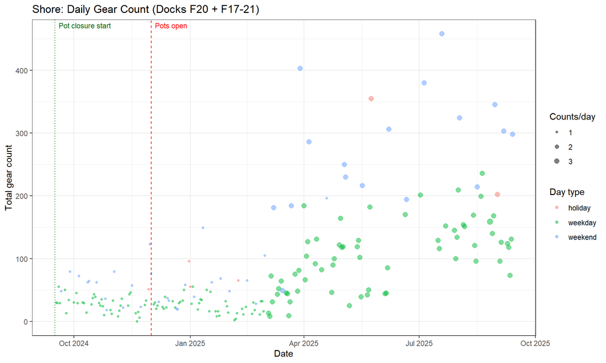

Shore effort (gear counts) over the season by day type.

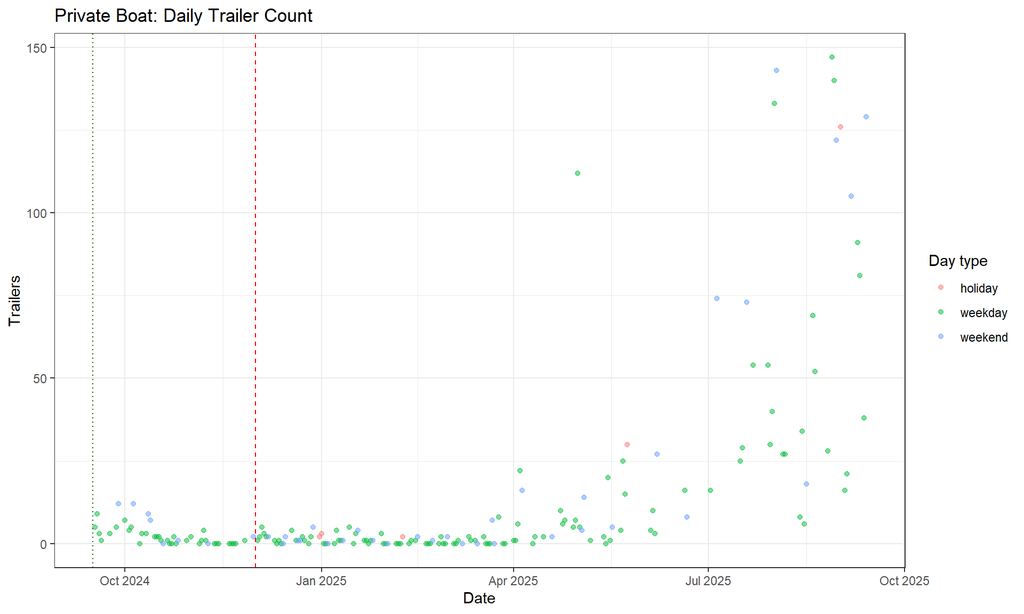

Private-boat effort (trailer counts) over the season by day type.

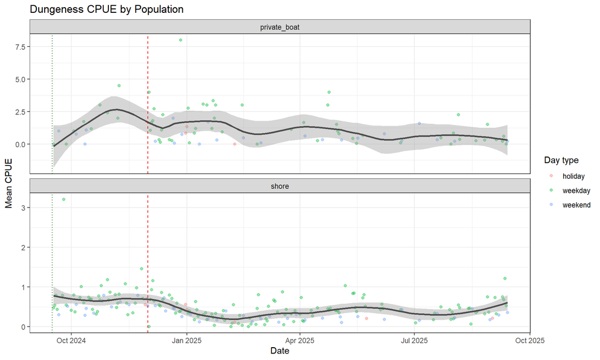

Interview CPUE over the season.

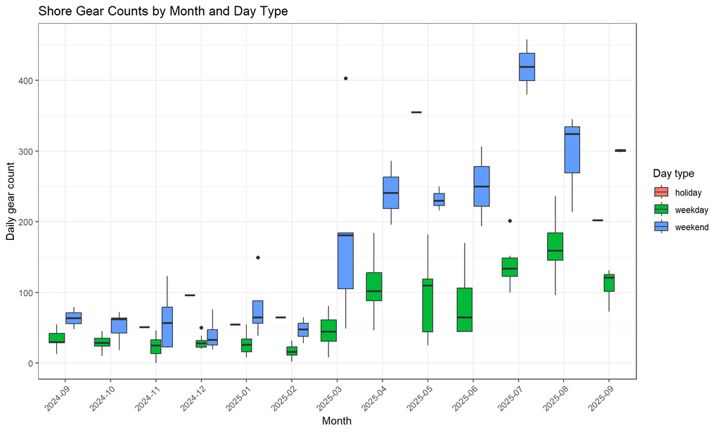

Effort by month.

```r
for (nm in c('p_shore_effort','p_boat_effort','p_cpue','p_effort_month')) if (exists(nm)) print(get(nm))
```

## 3.5 Other-fishery opener spillover (diagnostic)

A hypothesis test, not a model change: do other coastal fishery openers pull effort or catch onto (or off of) crab days enough to deserve their own day category, the way crabbing holidays already do? Two openers are checked against the crab effort and CPUE series: Marine Area 2 finfish (salmon, halibut, bottomfish) from the MA2 opener calendar, and coastal razor-clam digs on the beaches nearest Grays Harbor (Twin Harbors, Copalis, Mocrocks) from the dig calendar. Because these openers cluster on weekends and in particular months, which already drive crab effort, the raw opener-vs-other comparison is shown alongside an **adjusted** association: the opener’s coefficient in `lm(response ~ day_type + month + opener)`, i.e. the marginal effect after the weekend and monthly signal are removed. Read the adjusted column as the real test. This section changes no estimate; it only reports the associations so the analyst can decide whether to add an opener day category on a later run.

```r
# ---- 3.5 OTHER-FISHERY OPENER SPILLOVER (diagnostic; changes no estimate) ----
spillover <- NULL; sp_raw_disp <- NULL; sp_adj_disp <- NULL; p_spill_eff <- NULL; p_spill_cpue <- NULL
if (isTRUE(params$run_fishery_spillover_diag)) {
  timer_start("2b_fishery_spillover")
  spillover <- tryCatch(
    diagnose_fishery_spillover(dwg, params),
    error = function(e) { cat(sprintf("  Fishery-opener spillover diagnostic skipped: %s\n", conditionMessage(e))); NULL })
  if (!is.null(spillover)) {
    write.csv(spillover$raw,      file.path(output_dir, "fishery_spillover_raw.csv"),      row.names = FALSE)
    write.csv(spillover$adjusted, file.path(output_dir, "fishery_spillover_adjusted.csv"), row.names = FALSE)
    for (nt in spillover$notes) cat("  NOTE:", nt, "\n")

    sp_raw_disp <- spillover$raw |>
      dplyr::transmute(Series, Opener,
        `n (opener)` = n_opener, `Mean (opener)` = round(mean_opener, 2),
        `n (other)`  = n_other,  `Mean (other)`  = round(mean_other, 2),
        `Raw diff`   = round(raw_diff, 2), `Raw %` = round(raw_pct, 0),
        `t-test p`   = round(t_p, 3))
    sp_adj_disp <- spillover$adjusted |>
      dplyr::transmute(Series, Opener,
        `Adj. estimate` = round(adj_estimate, 2), SE = round(se, 2),
        `95% CI` = ifelse(is.na(ci_lo), "-", sprintf("[%.1f, %.1f]", ci_lo, ci_hi)),
        p = round(adj_p, 3), Note = note)

    mk_long <- function(df) df |>
      tidyr::pivot_longer(dplyr::all_of(spillover$flag_cols), names_to = "opener", values_to = "is_open") |>
      dplyr::mutate(Opener = unname(spillover$flag_labels[opener]),
                    Status = ifelse(is_open, "Opener", "Other"))
    p_spill_eff <- ggplot(mk_long(spillover$effort_long), aes(Status, value, fill = Status)) +
      geom_boxplot(outlier.size = 0.5, alpha = 0.85) +
      facet_grid(series ~ Opener, scales = "free_y") +
      scale_fill_manual(values = c(Opener = "#c0392b", Other = "grey70")) +
      labs(title = "Crab effort: other-fishery opener days vs other days", x = NULL, y = "Daily effort count") +
      theme_bw() + theme(legend.position = "none", axis.text.x = element_text(angle = 20, hjust = 1))
    p_spill_cpue <- ggplot(mk_long(spillover$cpue_long), aes(Status, value, fill = Status)) +
      geom_boxplot(outlier.size = 0.5, alpha = 0.85) +
      facet_grid(series ~ Opener, scales = "free_y") +
      scale_fill_manual(values = c(Opener = "#c0392b", Other = "grey70")) +
      labs(title = "Interview CPUE: other-fishery opener days vs other days", x = NULL, y = "Dungeness per crabber-hour") +
      theme_bw() + theme(legend.position = "none", axis.text.x = element_text(angle = 20, hjust = 1))
  }
  timer_stop("2b_fishery_spillover")
}
```

Raw comparison: mean crab effort (daily counts) and CPUE (Dungeness per crabber-hour) on other-fishery opener days vs other days. These are confounded with day-type and season; read the adjusted table below for the marginal effect.

| Series | Opener | n (opener) | Mean (opener) | n (other) | Mean (other) | Raw diff | Raw % | t-test p |
| --- | --- | --- | --- | --- | --- | --- | --- | --- |
| Shore gear (effort) | MA2 salmon open | 33 | 186.82 | 164 | 59.76 | 127.06 | 213 | 0.00 |
| Shore gear (effort) | MA2 halibut open | 23 | 150.96 | 174 | 71.80 | 79.16 | 110 | 0.00 |
| Shore gear (effort) | MA2 bottomfish open | 103 | 124.66 | 94 | 33.24 | 91.42 | 275 | 0.00 |
| Shore gear (effort) | Razor dig (nearby beaches) | 69 | 66.41 | 128 | 88.93 | -22.52 | -25 | 0.05 |
| Boat trailers (effort) | MA2 salmon open | 32 | 61.38 | 154 | 3.87 | 57.50 | 1,486 | 0.00 |
| Boat trailers (effort) | MA2 halibut open | 22 | 61.32 | 164 | 7.38 | 53.93 | 730 | 0.00 |
| Boat trailers (effort) | MA2 bottomfish open | 100 | 24.65 | 86 | 1.10 | 23.55 | 2,131 | 0.00 |
| Boat trailers (effort) | Razor dig (nearby beaches) | 64 | 3.88 | 122 | 18.95 | -15.08 | -80 | 0.00 |
| Shore CPUE | MA2 salmon open | 885 | 0.83 | 2,712 | 0.89 | -0.05 | -6 | 0.21 |
| Shore CPUE | MA2 halibut open | 527 | 0.91 | 3,070 | 0.87 | 0.05 | 5 | 0.37 |
| Shore CPUE | MA2 bottomfish open | 2,214 | 0.86 | 1,383 | 0.90 | -0.04 | -4 | 0.29 |
| Shore CPUE | Razor dig (nearby beaches) | 1,365 | 0.90 | 2,232 | 0.86 | 0.04 | 5 | 0.24 |
| Boat CPUE | MA2 salmon open | 32 | 2.45 | 130 | 3.42 | -0.97 | -28 | 0.05 |
| Boat CPUE | MA2 halibut open | 19 | 3.31 | 143 | 3.22 | 0.09 | 3 | 0.92 |
| Boat CPUE | MA2 bottomfish open | 73 | 2.68 | 89 | 3.67 | -0.99 | -27 | 0.03 |
| Boat CPUE | Razor dig (nearby beaches) | 62 | 3.64 | 100 | 2.97 | 0.67 | 23 | 0.17 |

Adjusted association: the opener coefficient in lm(response ~ day-type + month + opener), the marginal effect after removing the weekend and monthly signal the model already captures. Positive = more effort/CPUE on opener days. A blank estimate with a Note means the opener could not be separated from day-type/month in this season.

| Series | Opener | Adj. estimate | SE | 95% CI | p | Note |
| --- | --- | --- | --- | --- | --- | --- |
| Shore gear (effort) | MA2 salmon open | -3.19 | 52.97 | [-107.0, 100.6] | 0.95 |  |
| Shore gear (effort) | MA2 halibut open | 16.32 | 16.33 | [-15.7, 48.3] | 0.32 |  |
| Shore gear (effort) | MA2 bottomfish open | 24.28 | 15.76 | [-6.6, 55.2] | 0.12 |  |
| Shore gear (effort) | Razor dig (nearby beaches) | 17.12 | 7.84 | [1.8, 32.5] | 0.03 |  |
| Boat trailers (effort) | MA2 salmon open | -10.77 | 22.06 | [-54.0, 32.5] | 0.63 |  |
| Boat trailers (effort) | MA2 halibut open | 29.39 | 6.56 | [16.5, 42.2] | 0.00 |  |
| Boat trailers (effort) | MA2 bottomfish open | 1.50 | 7.17 | [-12.6, 15.6] | 0.84 |  |
| Boat trailers (effort) | Razor dig (nearby beaches) | 1.00 | 3.40 | [-5.7, 7.7] | 0.77 |  |
| Shore CPUE | MA2 salmon open | 0.56 | 0.23 | [0.1, 1.0] | 0.01 |  |
| Shore CPUE | MA2 halibut open | -0.05 | 0.08 | [-0.2, 0.1] | 0.50 |  |
| Shore CPUE | MA2 bottomfish open | 0.06 | 0.10 | [-0.1, 0.3] | 0.54 |  |
| Shore CPUE | Razor dig (nearby beaches) | 0.01 | 0.04 | [-0.1, 0.1] | 0.76 |  |
| Boat CPUE | MA2 salmon open | -1.26 | 3.02 | [-7.2, 4.7] | 0.68 |  |
| Boat CPUE | MA2 halibut open | 0.87 | 1.05 | [-1.2, 2.9] | 0.41 |  |
| Boat CPUE | MA2 bottomfish open | 2.00 | 1.59 | [-1.1, 5.1] | 0.21 |  |
| Boat CPUE | Razor dig (nearby beaches) | -0.24 | 0.56 | [-1.3, 0.9] | 0.68 |  |

**Identifiability notes (read before interpreting):**

- Nearby-dig vs any-dig agree on 197 of 197 sampled shore days (differ on 0); when 0, the nearby flag is not separable from a generic dig day this season.
- Opener OPEN-day counts in the sampled shore-effort series: salmon 33, halibut 23, bottomfish 103, nearby dig 69 (of 197 sampled days).
- Bottomfish is open most of the year (near-constant), and salmon is open only in summer (near-collinear with month); read those adjusted estimates with care.

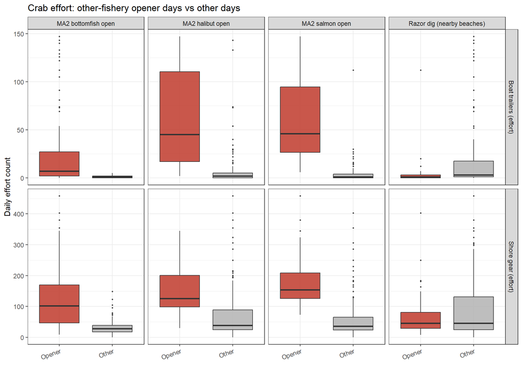

Crab effort on other-fishery opener days vs other days, by opener and series.

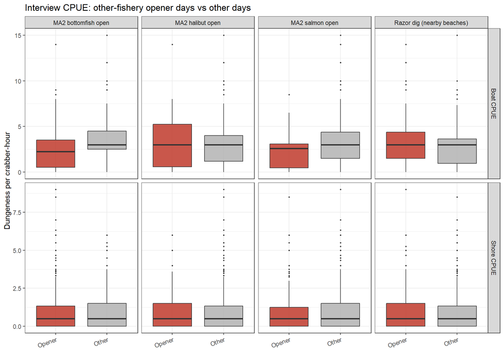

Interview CPUE on other-fishery opener days vs other days, by opener and series.

### 3.6 Other-fishery opener effort covariates (improvement 4)

Which other-fishery openers, if any, enter the EFFORT model this run, and why. `params$opener_covariate_mode` selects `"off"` (no covariates, the historical default), `"manual"` (an explicit list per population), or `"auto"` (include a candidate only if the spillover diagnostic’s day-type/month-**adjusted** effect on that population’s effort series clears `params$opener_auto_p` after a multiplicity adjustment across the eight effort tests).

**Read the screen as a screen, not a verdict.** Selecting a covariate on a p-value from the same data that then fits it inflates the coefficient and understates its uncertainty, and with eight tests about one false positive is expected at a raw alpha of 0.05. The default adjustment is Benjamini-Hochberg for that reason. The arbiter is predictive: refit with `opener_covariate_mode = "off"` and compare the effort-stream `elpd_loo`. The project’s one worked example is instructive, razor-dig on shore effort came in at p = 0.045, was fitted as `B3` in Run 3, and produced no predictive gain on any stream; under the default adjustment it does not survive the screen, while MA2 halibut on boat trailers (p = 3.6e-06) does.

**One interaction to hold in mind before switching on a boat opener.** Boat effort counts all private boats, so a halibut term legitimately describes that series, but the boats it captures are not crabbing. A constant crabbing fraction `f` converts the fitted surge into crab effort at the same rate as any other day, so fitting the surge better while multiplying it by a flat `f` makes the boat catch more biased on those days, not less. Pair a boat opener covariate with `crab_fraction_strata = "opener"` or `"month_opener"`; the chunk warns if you do not.

```r
# --- improvement 4: opener effort covariates ---------------------------------------
# Per-date opener flags for every candidate, used both by the screen and to build each
# fit's X_open matrix. Guarded: a missing calendar disables the feature, never the run.
params$opener_flags <- tryCatch(opener_flag_series(params),
                                error = function(e) { cat("  Opener calendar unavailable:",
                                                          conditionMessage(e), "\n"); NULL })

# Compatibility switch: razor_dig_mode still works and is implemented as one column of
# the opener machinery, so a razor-only run reproduces the retired B3 term exactly.
# It keeps its historical RAW (unadjusted) p-value rule on purpose, so a run pinned to
# the old behaviour is not silently re-decided by the new multiplicity adjustment.
params$razor_dig_dates <- tryCatch({
  ev <- prep_fishery_events(params)
  ev$razor |> dplyr::filter(razor_nearby_dig) |> dplyr::pull(event_date)
}, error = function(e) as.Date(character(0)))

razor_mode   <- tolower(params$razor_dig_mode %||% "no")
razor_thresh <- params$razor_dig_auto_p %||% 0.05
razor_auto_p <- NA_real_
if (razor_mode == "auto" && !is.null(spillover)) {
  ap <- spillover$adjusted |>
    dplyr::filter(Series == "Shore gear (effort)", grepl("Razor", Opener))
  if (nrow(ap) > 0) razor_auto_p <- ap$adj_p[1]
}
params$razor_dig_active <- switch(razor_mode,
  yes  = TRUE,
  no   = FALSE,
  auto = is.finite(razor_auto_p) && razor_auto_p < razor_thresh,
  FALSE)
if (razor_mode == "auto" && is.null(spillover))
  cat("  NOTE: razor_dig_mode = 'auto' but the spillover diagnostic is off ",
      "(run_fishery_spillover_diag = FALSE); the razor term stays OFF.\n", sep = "")

# The generalized screen.
opener_sel <- tryCatch(opener_select(spillover, params),
                       error = function(e) { cat("  Opener screen failed:", conditionMessage(e), "\n")
                                             list(shore = character(0), private_boat = character(0),
                                                  table = NULL, mode = "off", note = "screen failed") })
params$opener_selected <- list(shore = opener_sel$shore, private_boat = opener_sel$private_boat)

cat(sprintf("Opener effort covariates: mode=%s\n  shore: %s\n  private boat: %s\n",
            opener_sel$mode,
            if (length(opener_sel$shore)) paste(opener_sel$shore, collapse = ", ") else "(none)",
            if (length(opener_sel$private_boat)) paste(opener_sel$private_boat, collapse = ", ") else "(none)"))
```

```
## Opener effort covariates: mode=off
##   shore: (none)
##   private boat: (none)
```

```r
if (length(opener_sel$note)) cat("  ", opener_sel$note, "\n", sep = "")
```

```
##   opener_covariate_mode = 'off'; no opener covariates.
```

```r
cat(sprintf("Razor-dig compatibility switch: mode=%s, active=%s%s\n",
    razor_mode, params$razor_dig_active,
    if (razor_mode == "auto")
      sprintf(" (RAW adjusted shore-effort p=%s, threshold=%.3f)",
              ifelse(is.finite(razor_auto_p), sprintf('%.3f', razor_auto_p), 'NA'), razor_thresh)
    else ""))
```

```
## Razor-dig compatibility switch: mode=no, active=FALSE
```

```r
# --- the f interaction warning (improvement 4 x improvement 8) ---------------------
if (length(opener_sel$private_boat) > 0 &&
    !identical(params$crab_fraction_strata %||% "none", "opener") &&
    !identical(params$crab_fraction_strata %||% "none", "month_opener") &&
    isTRUE(params$use_crab_fraction)) {
  cat(paste0("\n  *** WARNING: a BOAT opener covariate is active while crab_fraction_strata = '",
             params$crab_fraction_strata %||% "none", "'.\n",
             "      The covariate makes latent boat effort track the opener-day surge in ALL-boat\n",
             "      counts more faithfully, and a constant f then converts that surge to crab effort\n",
             "      at the same rate as a closed-fishery day. Those are exactly the boats we know are\n",
             "      NOT crabbing, so this combination can INCREASE the boat bias on opener days.\n",
             "      Set crab_fraction_strata = 'opener' or 'month_opener' (params$opener_f_flag picks\n",
             "      which opener defines the stratum). ***\n\n"))
}

# Days on which the f-defining opener was open, for crab_fraction_strata = opener /
# month_opener. Harmless when those strata are not in use.
params$opener_f_dates <- tryCatch({
  fl <- params$opener_flags; ff <- params$opener_f_flag %||% "ma2_halibut_open"
  if (!is.null(fl) && ff %in% names(fl)) fl$event_date[as.logical(fl[[ff]])] else as.Date(character(0))
}, error = function(e) as.Date(character(0)))
```

[output not shown]

### 3.1 Ingress/egress and effective day length

The I/E surveys measure how long crabbers are actually present, which sets the effective day length used to expand snapshot effort counts. Civil twilight (9 to 17 hours) would overstate active fishing time by roughly a factor of two, so the I/E-derived length is used instead.

```r
# ---- 7.1b I/E ANALYSIS ----
cat("\n", strrep("=",60), "\n I/E ANALYSIS\n", strrep("=",60), "\n")

if(nrow(ie_data) > 0) {
  ie_validation <- ie_data |>
    filter(population == "shore") |>
    left_join(
      dwg$shore_effort |>
        group_by(event_date) |>
        summarise(mean_gear = mean(count_quantity), n_counts = n(), .groups = "drop"),
      by = "event_date"
    ) |>
    filter(!is.na(mean_gear), mean_gear > 0)

  if(nrow(ie_validation) > 0) {
    # Shared helper (03_R_functions/bss_day_length.R) so the [9, 17] cap lives in
    # exactly one place; this previously hardcoded a 16.0 cap.
    ie_validation$day_length_ct <- bss_day_length_civil(ie_validation$event_date, params)

    summ_shore_full <- prep_population_summary(dwg, "shore", params$est_date_start, params$est_date_end, params)
    cpg <- summ_shore_full$crabbers_per_gear

    ie_validation <- ie_validation |>
      mutate(
        gear_est_crabber_hrs = mean_gear * cpg * day_length_ct,
        f_temporal = ie_crabber_hours / gear_est_crabber_hrs,
        pct_error = (gear_est_crabber_hrs - ie_crabber_hours) / ie_crabber_hours * 100
      )

    cat("\n  I/E vs Gear-Count Comparison (paired days):\n")
    for(i in 1:nrow(ie_validation)) {
      r <- ie_validation[i,]
      cat(sprintf("  %-12s %-8s IE=%.0f Gear_est=%.0f f=%.2f\n",
                  as.character(r$event_date), r$day_type, r$ie_crabber_hours,
                  r$gear_est_crabber_hrs, r$f_temporal))
    }
    # 2026-08-27: report the deployment-scale columns too. ie_trips is the observation the
    # shore likelihood consumes under gear-deployments (improvement 1/A); turnover is what
    # `L` carries there; hours_per_trip is their ratio and should sit near the
    # interview-reported trip length (~3.2 h). Without these three, this file could not be
    # used to audit the unit the model actually ran on.
    write.csv(ie_validation |>
      mutate(turnover       = if_else(max_present > 0, ie_trips / max_present, NA_real_),
             hours_per_trip = if_else(ie_trips > 0, ie_crabber_hours / ie_trips, NA_real_)) |>
      select(event_date, day_type, ie_crabber_hours, ie_trips, max_present, mean_present,
             L_effective, turnover, hours_per_trip,
             mean_gear, n_counts, gear_est_crabber_hrs, f_temporal, pct_error),
      file.path(output_dir, "ie_analysis.csv"), row.names = FALSE)
  }
} else {
  cat("  No I/E data available.\n")
}
```

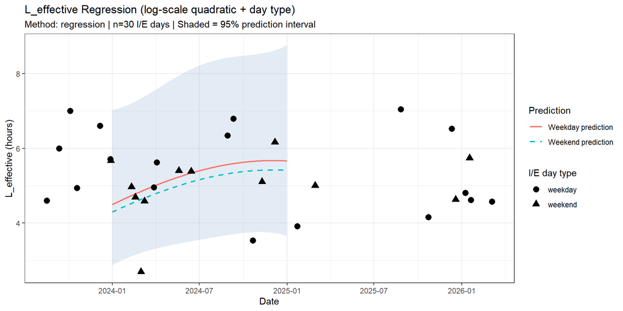

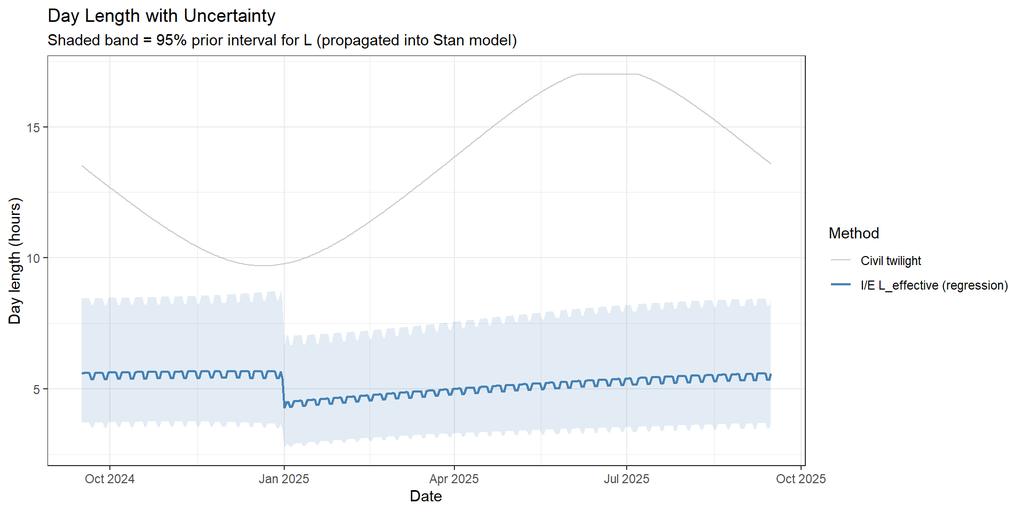

```r
for (nm in c('p_L_regression','p_day_length')) if (exists(nm)) print(get(nm))
```

### 3.2 Shore I/E representativeness (diagnostic)

The shore all-gear `sigma_IE` (~1.07 in the 2026-07-12 run, vs ~0.60 in the gear-resolved fit) means the I/E-derived effective day length and the effort counts disagree by roughly a factor of `e` at the tails. This check asks whether that is because the shore I/E days were sampled on unusually high-effort days (so the derived day length is unrepresentative) or is just sparse-data scatter across a handful of I/E days: it compares the shore daily gear counts on I/E observation days against all other sampled days (item 4 / GR-9).

```
## **Shore I/E days: 6.** I/E days skew toward LOWER-effort days (mean percentile 0.27, rank-test p = 0.06).
```

Shore daily gear counts on I/E observation days vs other sampled days. A mean percentile rank near 0.5 with a non-significant rank test means the I/E days are representative, so a large shore sigma_IE reflects sparse-data scatter, not sampling on peak-effort days.

| group | n | mean_gear | median_gear |
| --- | --- | --- | --- |
| I/E days | 6 | 43.2 | 23.5 |
| non-I/E days | 191 | 82.2 | 47.0 |

## 4. Point Estimator (PE)

The design-based estimator: it averages sampled days within each stat-week by day-type stratum and expands to the unsampled days. The PE is fast and transparent, and it is the fallback whenever a Bayesian fit does not pass the convergence gate.

```r
# ---- 7.2 PE ESTIMATES ----
timer_start("3_PE_estimates")
cat("\n", strrep("=",60), "\n PE ESTIMATES\n", strrep("=",60), "\n")

pe_all <- list()
for(pop in c("shore","private_boat")) {
  for(ss in subseasons) {
    label <- paste0(pop, "_", ss$name)
    days_ss <- prep_days_crab(ss$start, ss$end, params, L_eff_model = L_eff_model)
    summ_ss <- prep_population_summary(dwg, pop, ss$start, ss$end, params)
    pe_all[[label]] <- run_pe_pooled(summ_ss, days_ss, params, label)
  }
}
# 2026-08-27: the empty-effort-stratum audit as a FILE, not a console line. This chunk is
# results='hide', so the per-component report run_pe_pooled() cat()s never reached a reader
# on this track. See write_pe_empty_stratum_report() in 03_R_functions/save_run_diagnostics.R.
pe_empty_report <- write_pe_empty_stratum_report(pe_all, output_dir, params)
timer_stop("3_PE_estimates")
```

### 4.1 Incomplete-trip treatment diagnostic (improvement 5)

An incomplete trip is one where the crabber had not finished when we spoke to them. Their gear is all in the catch-rate denominator; only part of their catch is in the numerator, so the measured rate reads low (about -21% for pots, -23% for traps, -20% for snares; ring nets are effectively exempt at +4%). Production drops them, at a cost of roughly 36% of the interview sample.

**The structural fact that bounds what any treatment can do.** Effort in this pipeline does not come from interviews. It comes from the dock gear counts and the trailer/OSP boat counts. Interviews supply only the catch **rate** and the gear **ratios** (`R_G`, gear per crabber; `R_G_boat` / the PE’s gear-per-group). So no treatment of incomplete trips can add effort to the expansion; each arm below moves the estimate through the catch rate or through the gear ratios, and nothing else.

Four arms are run against the fast design-based PE. **This section changes no reported number**; the production estimator remains `exclude`.

- **exclude**, production today: drop them from both the catch rate and the gear ratios.
- **gear_only**, drop their catch, keep their gear counts in the gear ratios. An interrupted trip’s gear count is fully observed; only its catch is truncated. *The pipeline does not do this today*: `prep_bss_crab_*()` builds the `R_G` / `R_G_boat` interview set from the already-filtered frame, so an incomplete trip’s gear count is currently discarded. Note also that the PE and the BSS disagree on this point; `run_pe_*()` computes the boat gear-per-group from the **unfiltered** set, so the boat PE already behaves like `gear_only` while the boat BSS behaves like `exclude`.
- **impute_mean_cpue**, keep them with catch replaced by (complete-trip catch rate × their gear count). Expect close to no movement, and that is arithmetic rather than luck: a ratio-of-sums over complete-plus-imputed returns the complete-trip rate identically. Any movement is thin-stratum shrinkage toward the pooled rate.
- **keep**, no filter (pre-v7.5 behaviour).

Read `gear_ratio` and `gear_lengthbias_p` before acting on `gear_only`: intercepted trips over-represent long trips by construction, and if long trips also deploy more gear then folding them into `R_G` would bias the effort expansion up.

Not implemented here, and the statistically correct answer: a **censored likelihood**, in which an incomplete trip’s observed catch is treated as a lower bound (`neg_binomial_2_lccdf`) rather than an observation. That recovers the whole sample without the bias, but it is a Stan change with a validation burden and cannot be evaluated by a design-based arm. See `PIPELINE_STATUS.md` Tier 2.

```r
# ---- 7.2b POOL-2 / improvement 5: INCOMPLETE-TRIP TREATMENT DIAGNOSTIC ----
# Four arms through the fast design-based PE (no MCMC). DIAGNOSTIC ONLY: it changes no
# reported total and is tryCatch-wrapped so it can never break the run. The arm logic and
# the reasoning behind each arm live in 03_R_functions/diagnose_incomplete_trips.R.
# Output: sensitivity_incomplete_trips.csv.
cat("\n", strrep("=",60), "\n INCOMPLETE-TRIP TREATMENT DIAGNOSTIC (improvement 5)\n", strrep("=",60), "\n")
sens_df <- NULL   # persists to the display chunk below even if the tryCatch errors
if (isTRUE(params$diagnose_incomplete_trips %||% TRUE)) {
  tryCatch({
    sens_df <- diagnose_incomplete_trips(dwg, subseasons, params, L_eff_model,
                                         pe_fun = run_pe_pooled)
    if (!is.null(sens_df))
      write.csv(sens_df, file.path(output_dir, "sensitivity_incomplete_trips.csv"), row.names = FALSE)
  }, error = function(e) cat(sprintf("  Incomplete-trip diagnostic skipped: %s\n", conditionMessage(e))))
}
```

[output not shown]

### 4.2 Commercial and charter census

The commercial and charter harvest is a day-type-stratified census expansion of the daily vessel tally, not a modeled quantity. As of the T1.4 change it uses a **separate mean catch per vessel for commercial vs charter vessels**, each applied to its own tally column, rather than one mean across the pooled tally; the two classes have different catch profiles, so a single mean biased the total whenever the commercial-to-charter mix in the tally differed from the mix in the interviews.

```r
# ---- 7.4 COMMERCIAL/CHARTER ----
timer_start("4_commercial_charter")
pe_all$comm_charter <- estimate_comm_charter(dwg, params)
timer_stop("4_commercial_charter")
```

Commercial vs charter split behind the census (T1.4). Each class’s mean catch per vessel is applied to its own tally column instead of one pooled mean. ‘Sampled-day catch’ is the class census before the day-type expansion that produces the reported commercial/charter total, so it shows the split, not the final stratified figure.

| Vessel type | Interviews | Mean Dungeness/vessel | Tally vessels (window) | Sampled-day catch |
| --- | --- | --- | --- | --- |
| Commercial | 140 | 39.3 | 164 | 6,451 |
| Charter | 20 | 64.3 | 23 | 1,479 |

### 4.3 PE port totals

The Point Estimator port total, summed across the three population components. Compare it against the Bayesian total below.

```r
# ---- 7.5 PE PORT TOTALS ----
cat("\n", strrep("=",60), "\n PE PORT TOTALS\n", strrep("=",60), "\n")

# component_keys / component_names now follow the sub-season set (build_subseasons):
# one row per population x sub-season, then comm_charter, then a PORT TOTAL computed from
# the semantic sums (pe_port_total), not by a fixed row index. component_keys is still
# consumed by the PE-consistency check chunk below (comm_charter has no check, skipped there).
pe_pops    <- c("shore", "private_boat")
pop_disp   <- c(shore = "Shore", private_boat = "Private Boat")
ss_names   <- vapply(subseasons, function(ss) ss$name,         character(1))
ss_disp    <- vapply(subseasons, function(ss) ss$display_name, character(1))
component_keys  <- c(unlist(lapply(pe_pops, function(p) paste0(p, "_", ss_names))), "comm_charter")
component_names <- c(unlist(lapply(pe_pops, function(p) sprintf("%s (%s)", pop_disp[[p]], ss_disp))),
                     "Commercial/Charter")

pe_summary <- tibble(
  Component  = c(component_names, "PORT TOTAL"),
  Effort_hrs = c(vapply(component_keys, function(k) pe_field(k, "effort_total"),  numeric(1)), pe_port_total("effort_total")),
  Dungeness  = c(vapply(component_keys, function(k) pe_field(k, "Dungeness_Kept"), numeric(1)), pe_port_total("Dungeness_Kept"))
)
if(params$estimate_red_rock) {
  pe_summary$Red_Rock <- c(vapply(component_keys, function(k) pe_field(k, "Red_Rock_Kept"), numeric(1)),
                           pe_port_total("Red_Rock_Kept"))
}

print(pe_summary |> mutate(across(where(is.numeric), ~round(.))))
write.csv(pe_summary, file.path(output_dir, "pe_port_summary.csv"), row.names=FALSE)
```

```r
report_table(pe_summary, 'Point Estimator (PE) port totals by component.')
```

Point Estimator (PE) port totals by component.

| Component | Effort_hrs | Dungeness |
| --- | --- | --- |
| Shore (Pot closure) | 4,661.26 | 5,959.14 |
| Shore (All gear) | 18,862.73 | 15,755.14 |
| Private Boat (Pot closure) | 180.21 | 400.30 |
| Private Boat (All gear) | 3,708.75 | 11,169.63 |
| Commercial/Charter | 278.55 | 11,821.13 |
| PORT TOTAL | 27,691.49 | 45,105.33 |

### 4.4 PE internal consistency (ratio-of-sums)

Each component’s PE stratum CPUE is a ratio-of-sums (`sum(catch)/sum(hrs)` within each week-by-day-type stratum), not a mean of per-day ratios (backlog P0). The mean-of-ratios was unstable in thin strata, a day with very little sampled effort produced an extreme daily ratio that was then multiplied by the full stratum effort, and it made the shore PE’s implied CPUE about 2.9x its own interview ratio-of-sums. Ratio-of-sums removes that and matches the gear-resolved track. The check below is the guardrail: the PE’s implied CPUE (its catch divided by its effort) must agree with the ratio-of-sums over the same interviews. A ratio far from 1 means catch and effort are on different scales, and the run stops if any component exceeds 2x, so a clean table here is itself the confirmation that the PE is internally consistent.

PE internal-consistency check (P0). ‘PE implied CPUE’ is the component’s PE catch / PE effort; ‘Interview RoS’ is the ratio-of-sums over the same interviews. Healthy: Ratio near 1 (the run stops if any component is below 0.5 or above 2.0).

| Component | Unit | PE implied CPUE | Interview RoS | Ratio |
| --- | --- | --- | --- | --- |
| shore pot-closure | gear-deployments | 1.28 | 1.26 | 1.02 |
| shore all-gear | gear-deployments | 0.84 | 0.87 | 0.96 |
| boat pot-closure | gear-deployments | 2.22 | 2.29 | 0.97 |
| boat all-gear | gear-deployments | 3.01 | 3.36 | 0.90 |

## 5. Bayesian state-space model fits

Each population by sub-season is fit independently with a Bayesian state-space (BSS) model that treats daily effort and catch rate as smoothly evolving latent series, fills the gaps between sampled days, and returns full credible intervals. **What a healthy fit looks like:** R-hat below 1.01, effective sample size above 400, and few or no divergent transitions on every monitored quantity. Fits are checked against these criteria in the next section.

```r
# ---- 7.6 BSS MODEL RUNS ----
timer_start("5_BSS_model_runs")
cat("\n", strrep("=",60), "\n BSS MODEL RUNS (Adaptive AR)\n", strrep("=",60), "\n")

bss_catch_groups <- catch_groups
bss_all <- list()
ar_resolutions <- list()  # track AR resolution per fit (the FINAL attempt's, when escalating)
ar_escalation_log <- list()  # improvement 7: one row per fit attempt (see ar_escalation_log.csv)
.kept_attempt <- list()      # fit label -> the attempt index whose stanfit was retained

for(cg in bss_catch_groups) {
  for(pop in c("shore","private_boat")) {
    for(ss in subseasons) {
      label <- paste0(pop, "_", ss$name, "_", cg)
      cat(sprintf("\n--- BSS: %s ---\n", label))

      days_ss <- prep_days_crab(ss$start, ss$end, params, L_eff_model = L_eff_model)
      summ_ss <- prep_population_summary(dwg, pop, ss$start, ss$end, params)

      # NOTE (POOL-2): n_int is the UNFILTERED interview count. The fitted CPUE
      # count is lower once prep_bss_crab drops h<=0 rows and (with
      # filter_incomplete_trips = TRUE) incomplete trips, so this sufficiency
      # guard reads looser than the count the fit actually uses. Behavior is
      # unchanged from prior versions (the guard was always pre-filter); on the
      # 2024-25 data every fitted component keeps well over bss_min_interviews
      # complete interviews. If a future component is marginal, gate on the
      # complete-only count instead.
      n_int <- nrow(summ_ss$interview)
      n_eff <- nrow(summ_ss$effort_index)

      if(n_eff < 5 || n_int < params$bss_min_interviews) {
        cat(sprintf("  Insufficient data (%d effort, %d interviews), PE fallback.\n", n_eff, n_int))
        bss_all[[label]] <- list(C_sum=NA, E_sum=NA, pe_fallback=TRUE,
                                 population=pop, subseason=ss$name, catch_group=cg)
        next
      }

      # ================================================================================
      # improvement 7: AR RESOLUTION ESCALATION LADDER
      # --------------------------------------------------------------------------------
      # ar_escalate = FALSE (default) -> exactly one attempt at the resolution the
      # coverage rule picks, capped by ar_max_resolution. Identical to previous runs.
      #
      # ar_escalate = TRUE -> start at the FINEST rung (daily, ignoring the caps) and
      # refit one rung coarser each time the fit fails the SAME convergence gate that
      # decides PE-vs-BSS, stopping at the first rung that passes. Each rung is a real
      # multi-hour fit, so this is a deliberate runtime-for-guarantee trade; see
      # run_config.R. Every attempt is logged to ar_escalation_log.csv.
      #
      # The gate is computed here per attempt, on a minimal list(fit, pe_fallback), which
      # is exactly what bss_compute_gate() reads. The authoritative gate pass in Section 6
      # still recomputes it on the final fit, so the two cannot disagree.
      # ================================================================================
      eff_d_ladder <- summ_ss$effort_index |>
        filter(count_sequence <= params$bss_max_count_seq) |>
        left_join(days_ss |> select(event_date, day_index), by = "event_date") |>
        filter(!is.na(day_index))
      ar_ladder <- bss_ar_ladder(days_ss, eff_d_ladder, pop, params,
                                 fixed_resolution = NULL, gear_regime = ss$gear_regime)
      # Incumbent trackers for the rung-selection rule below. Reset per component.
      .incumbent_passed <- FALSE; .incumbent_pi_rel <- Inf
      # 2026-09-04: ar_escalate is resolved PER FIT, because it now accepts a per-population
      # or per-sub-season scope as well as a scalar (03_R_functions/bss_ar_resolution.R).
      # Every rung is a multi-hour fit, so escalating a component whose cap is already
      # settled burns known-bad fits to rediscover it.
      .esc_on <- .bss_resolve_ar_escalate(params, pop, ss$gear_regime)
      if (.esc_on)
        cat(sprintf("  AR escalation ladder [%s/%s]: %s\n", pop, ss$gear_regime,
                    paste(ar_ladder, collapse = " -> ")))

      # improvement 6: the POST-FILTER interview floor. The guard above counts UNFILTERED
      # interviews and therefore reads looser than the count the CPUE likelihood sees;
      # that was harmless at a floor of 20 with hundreds to spare and is not harmless at
      # 15 with the boat pot-closure's 17. NULL reuses bss_min_interviews.
      min_fitted <- params$bss_min_interviews_fitted %||% params$bss_min_interviews

      is_shore   <- (pop == "shore")
      is_boat    <- (pop == "private_boat")
      is_allgear <- (ss$gear_regime == "all_gear")
      is_ringnet <- (ss$gear_regime == "pot_closure")

      fit <- NULL; bss_data <- NULL; too_thin <- FALSE

      for (attempt in seq_along(ar_ladder)) {

        # force_resolution only when escalating: with the ladder off we must go through
        # the historical data-driven + cap path so the run is bit-comparable to Run 6.
        #
        # 2026-09-04 DEFECT FIX. This line read `isTRUE(params$ar_escalate)`. When
        # ar_escalate became scoped (`list(shore = "all_gear")`, or a character vector of
        # populations) on the same day, `isTRUE()` on a list is FALSE, so force_res stayed
        # NULL while `.esc_on` above correctly resolved TRUE. The ladder was therefore BUILT
        # with four rungs and the loop ran four attempts, but every attempt re-derived the
        # SAME resolution from the data-driven selector. The 2026-09-03 A1 stage fitted
        # shore all-gear at `daily` four consecutive times, 333 divergences and
        # catch_median 20,897.819 on every rung, and burned 14.7 h of a 23.6 h batch to
        # learn nothing. Resolve it the same way `.esc_on` does, from the one helper.
        force_res <- if (.esc_on) ar_ladder[attempt] else NULL
        bss_data_try <- prep_bss_crab_pooled(days_ss, summ_ss, cg, params, pop,
                                             gear_regime = ss$gear_regime, ie_data = ie_data,
                                             force_resolution = force_res)
```

```r
        n_fitted <- attr(bss_data_try, "n_interviews_fitted") %||% bss_data_try$IntC
        if (n_fitted < min_fitted) {
          cat(sprintf(paste0("  Post-filter interviews %d < bss_min_interviews_fitted = %d ",
                             "(pre-filter count was %d); PE fallback.\n"),
                      n_fitted, min_fitted, n_int))
          bss_all[[label]] <- list(C_sum=NA, E_sum=NA, pe_fallback=TRUE,
                                   population=pop, subseason=ss$name, catch_group=cg)
          too_thin <- TRUE
          break
        }

        # v6.1/v6.2: per-fit sampler tuning. Each branch sets iter, warmup,
        # max_treedepth, and adapt_delta; any fit without a specific override
        # uses the *_default values. Ported from the gear-resolved track (v6.1)
        # and extended with a boat all-gear branch (v6.2). The boat all-gear fit
        # produced 5998 divergences with treedepth_pct = 0 in the 2026-04-08 run,
        # so step size (adapt_delta), not trajectory length, was the binding
        # constraint: adapt_delta is raised to 0.99 and max_treedepth to 13 (the
        # smaller steps from a higher adapt_delta lengthen trajectories, so the
        # deeper tree is a buffer against new treedepth saturation).
        if(is_shore && is_allgear) {
          fit_iter    <- params$bss_iter_shore_allgear
          fit_warmup  <- params$bss_warmup_shore_allgear
          fit_treedep <- params$bss_treedepth_shore_allgear %||% params$bss_max_treedepth_default
          fit_delta   <- params$bss_delta_shore_allgear     %||% params$bss_adapt_delta
        } else if(is_boat && is_allgear) {
          fit_iter    <- params$bss_iter_boat_allgear      %||% params$bss_iter_default
          fit_warmup  <- params$bss_warmup_boat_allgear    %||% params$bss_warmup_default
          fit_treedep <- params$bss_treedepth_boat_allgear %||% params$bss_max_treedepth_default
          fit_delta   <- params$bss_delta_boat_allgear     %||% params$bss_adapt_delta
        } else if(is_ringnet) {
          fit_iter    <- params$bss_iter_default
          fit_warmup  <- params$bss_warmup_default
          fit_treedep <- params$bss_treedepth_ringnet %||% params$bss_max_treedepth_default
          fit_delta   <- params$bss_delta_ringnet     %||% params$bss_adapt_delta
        } else {
          fit_iter    <- params$bss_iter_default
          fit_warmup  <- params$bss_warmup_default
          fit_treedep <- params$bss_max_treedepth_default
          fit_delta   <- params$bss_adapt_delta
        }

        cat(sprintf("  Stan [attempt %d/%d]: iter=%d, warmup=%d, max_treedepth=%d, adapt_delta=%.2f, D=%d days, P_n=%d (%s), %d interviews\n",
                    attempt, length(ar_ladder), fit_iter, fit_warmup, fit_treedep, fit_delta,
                    bss_data_try$D, bss_data_try$P_n,
                    attr(bss_data_try, "ar_resolution"), bss_data_try$IntC))

        timer_start(paste0("BSS_", label, "_att", attempt))
        # 2026-08-26: guarded wrapper, 03_R_functions/bss_stan_fit.R. On the happy path
        # this is rstan::stan() with the same arguments, same seed, same RNG stream, so
        # fits are unchanged. It adds two pre/post checks that would have turned the
        # 2026-08-25 "dim(X) must have a positive length" failure into a one-line error
        # naming the missing Stan data variable: a data-completeness check before the
        # sampler, and an empty-stanfit check after it. log_file keeps the Stan console
        # for this fit in output_dir, so a chain failure stays diagnosable even though
        # this chunk is results='hide'.
        fit_try <- bss_stan_fit(
          file = here("02_stan_models", params$bss_model_file),
          data = bss_data_try,
          label = sprintf("%s att%d", label, attempt),
          log_file = file.path(output_dir,
                               sprintf("stan_console_%s_att%d.log", label, attempt)),
          chains = params$bss_chains, iter = fit_iter, warmup = fit_warmup,
          control = list(adapt_delta=fit_delta, max_treedepth=fit_treedep),
          seed = params$bss_seed,
          cores = params$bss_cores
        )
        timer_stop(paste0("BSS_", label, "_att", attempt))

        gate_try <- tryCatch(
          bss_compute_gate(list(fit = fit_try, pe_fallback = FALSE), label,
                           catch_par        = "C_expected_sum",
                           effort_par       = "E_sum",
                           max_impact_sd    = params$max_divergence_total_impact_sd %||% 0.10,
                           max_div_fraction = params$max_divergence_fraction %||% 0.05,
                           ar_resolution    = attr(bss_data_try, "ar_resolution")),
          error = function(e) NULL)

        # 2026-09-04: keep this rung's ANSWER, not only its sampler diagnostics. The loop
        # overwrites `fit` on the next attempt, so without this the estimate produced at
        # every rung except the surviving one is lost, and the whole reason to run a ladder
        # is to see how the answer depends on the resolution. It also makes
        # params$ar_escalate_select's precision tie-break implementable at all.
        .rung <- bss_ar_rung_summary(fit_try)
        ar_escalation_log[[length(ar_escalation_log) + 1]] <- tibble(
          fit                = label,
          attempt            = attempt,
          n_attempts_planned = length(ar_ladder),
          ar_resolution      = attr(bss_data_try, "ar_resolution") %||% NA_character_,
          P_n                = bss_data_try$P_n,
          escalation_enabled = .esc_on,
          divergences        = gate_try$divergences        %||% NA_integer_,
          divergence_fraction= gate_try$divergence_fraction %||% NA_real_,
          impact_C_sd        = gate_try$impact_C_sd        %||% NA_real_,
          pass_convergence   = gate_try$pass_convergence   %||% NA,
          # The rung's own estimate. catch_* is the expected-catch season total, the same
          # quantity the gate scores, so the verdict and the number refer to one thing.
          catch_median       = .rung$catch_median,
          catch_lo95         = .rung$catch_lo95,
          catch_hi95         = .rung$catch_hi95,
          pi_width           = .rung$pi_width,
          pi_width_rel       = .rung$pi_width_rel,
          effort_median      = .rung$effort_median,
          selected           = FALSE      # set on the surviving rung after the loop
        )
```

```r
        # ---- which rung's fit is kept ------------------------------------------
        # params$ar_escalate_stop:
        #   "first_pass" (DEFAULT, and the pre-2026-09-04 behaviour exactly): stop at the
        #      finest rung that passes the convergence gate and report it. Cheapest, and it
        #      is the production rule: a component reports at the finest resolution the
        #      sampler can actually support this season.
        #   "all_rungs": fit EVERY rung on the ladder and keep the one params$
        #      ar_escalate_select names. This is the DIAGNOSTIC mode. It costs one fit per
        #      rung but it answers, in a single run and a single output folder, how the
        #      estimate depends on resolution, which three separate forced runs answer far
        #      more expensively and with the rungs scattered across three folders.
        #
        # Only ONE stanfit beyond the incumbent is ever held in memory: the challenger
        # replaces the incumbent or is discarded immediately. Holding the whole ladder would
        # be several GB for a daily shore fit.
        .stop_rule   <- params$ar_escalate_stop   %||% "first_pass"
        .select_rule <- params$ar_escalate_select %||% "first_pass"
        .passed      <- is.null(gate_try) || isTRUE(gate_try$pass_convergence)
        .keep <- if (is.null(fit)) TRUE                    # nothing kept yet
                 else if (identical(.stop_rule, "first_pass")) TRUE
                 else if (!.passed) FALSE                  # never report a rung that failed
                 else if (!isTRUE(.incumbent_passed)) TRUE  # first passing rung wins outright
                 else if (identical(.select_rule, "narrowest_pi"))
                   isTRUE(.rung$pi_width_rel < (.incumbent_pi_rel %||% Inf))
                 else FALSE                                # "first_pass": keep the finest
        if (.keep) {
          bss_data <- bss_data_try; fit <- fit_try
          ar_resolutions[[label]] <- attr(bss_data_try, "ar_resolution")
          .incumbent_passed <- .passed
          .incumbent_pi_rel <- .rung$pi_width_rel
          # 2026-09-04: record the ATTEMPT NUMBER kept, not just its resolution. The
          # post-loop marker used to re-derive the selected row by matching the resolution
          # string and taking the last match, which is wrong whenever two rungs share a
          # resolution. On the 2026-09-03 A1 stage all four rungs read "daily", so the log
          # marked attempt 4 as reported while `.keep` had actually retained attempt 1.
          .kept_attempt[[label]] <- attempt
        }

        if (identical(.stop_rule, "all_rungs") && .esc_on) {
          if (attempt < length(ar_ladder)) {
            cat(sprintf("  [all_rungs] %s AR %s the gate; fitting %s next for the ladder.\n",
                        attr(bss_data_try, "ar_resolution"),
                        if (.passed) "PASSED" else "failed", ar_ladder[attempt + 1]))
            next
          } else break
        }

        if (.passed) break
        if (!.esc_on) break
        if (attempt < length(ar_ladder)) {
          cat(sprintf(paste0("  Gate FAILED at %s AR; escalating to %s and refitting ",
                             "(improvement 7 ladder).\n"),
                      attr(bss_data_try, "ar_resolution"), ar_ladder[attempt + 1]))
        } else {
          cat(paste0("  Gate FAILED at the coarsest rung on the ladder; this component will ",
                     "report the Point Estimator.\n"))
        }
      }

      if (too_thin) next

      # --- Extract BOTH expected and predictive catch ---
      bss_pars <- c("C_sum","C_expected_sum","E_sum","B1","B2","B1_C_out","B2_C_out")
      if(bss_data$IE_n > 0) bss_pars <- c(bss_pars, "sigma_IE_out")
      # improvement 4: B3_out (razor only) is replaced by the B_open_out vector; the
      # column labels live in attr(bss_data, "opener_labels").
      if(bss_data$K_open > 0) bss_pars <- c(bss_pars, "B_open_out")
      # improvement 8: report the OSP crab-only lower bound alongside f itself.
      if(isTRUE(bss_data$osp_crab_lower == 1L)) bss_pars <- c(bss_pars, "f_lower_out")
      if(bss_data$apply_crab_fraction == 1L) bss_pars <- c(bss_pars, "f_crab_out")
      if(isTRUE(params$estimate_cpue_density)) bss_pars <- c(bss_pars, "gamma_C_out")           # item 6b
      bss_summ <- summary(fit, pars=bss_pars)$summary
      cat("  BSS Summary:\n"); print(bss_summ)
      write.csv(as.data.frame(bss_summ), file.path(output_dir, paste0("bss_summary_",label,".csv")))

      # improvement 4: Stan reports B_open_out[1], B_open_out[2], ... with no idea which
      # opener each index is. Without this map an opener-active run's structural table is
      # unreadable. Written per fit because the surviving columns are per fit (a covariate
      # that is not identifiable inside one sub-season's window is dropped for that fit).
      .olab <- attr(bss_data, "opener_labels")
      if (length(.olab) > 0)
        write.csv(tibble(index = seq_along(.olab), parameter = sprintf("B_open_out[%d]", seq_along(.olab)),
                         opener = .olab),
                  file.path(output_dir, paste0("opener_covariates_", label, ".csv")), row.names = FALSE)

      C_draws <- rstan::extract(fit, "C_sum")$C_sum           # predictive (with Poisson noise)
      C_exp_draws <- rstan::extract(fit, "C_expected_sum")$C_expected_sum  # expected (no noise)
      E_draws <- rstan::extract(fit, "E_sum")$E_sum

      bss_all[[label]] <- list(
        C_sum = quantile(C_draws, c(0.025,0.5,0.975)),
        C_expected_sum = quantile(C_exp_draws, c(0.025,0.5,0.975)),
        E_sum = quantile(E_draws, c(0.025,0.5,0.975)),
        C_draws = C_draws, C_exp_draws = C_exp_draws, E_draws = E_draws,
        fit = fit, pe_fallback = FALSE, bss_data = bss_data, days_ss = days_ss,
        population = pop, subseason = ss$name, catch_group = cg
      )

      # --- Use C_expected (no Poisson noise) for primary estimates ---
      E_bss <- rstan::extract(fit, "E")$E
      C_exp_bss <- rstan::extract(fit, "C_expected")$C_expected
```

```r
      E_daily <- tibble(
        event_date = days_ss$event_date,
        median = apply(E_bss[,1,,1], 2, median),
        lo95 = apply(E_bss[,1,,1], 2, quantile, 0.025),
        hi95 = apply(E_bss[,1,,1], 2, quantile, 0.975)
      )

      C_daily <- tibble(
        event_date = days_ss$event_date,
        median = apply(C_exp_bss[,1,,1], 2, median),
        lo95 = apply(C_exp_bss[,1,,1], 2, quantile, 0.025),
        hi95 = apply(C_exp_bss[,1,,1], 2, quantile, 0.975)
      )

      # BSS effort plot
      p_bss_eff <- E_daily |>
        ggplot(aes(x = event_date)) +
        geom_ribbon(aes(ymin = lo95, ymax = hi95), alpha = 0.2, fill = "steelblue") +
        geom_line(aes(y = median), color = "steelblue") +
        labs(title = sprintf("BSS Daily Effort: %s", label),
             subtitle = sprintf("Median with 95%% credible interval (%s AR(1))",
                                attr(bss_data, "ar_resolution") %||% "adaptive"),
             # improvement 1: the axis said "Crabber-hours" long after the v7.6/v7.7 move
             # to gear-deployments. E carries the CPUE denominator's unit by construction
             # (bss_effort_spec), so read it from the fit's own data rather than hardcoding.
             x = "Date", y = sprintf("Effort (%s)", bss_data$.effort_unit %||% "gear-deployments")) +
        theme_bw()
      ggsave(file.path(output_dir, paste0("plot_bss_effort_", label, ".png")),
             p_bss_eff, width = 10, height = 6)

      # BSS catch plot (using expected catch)
      p_bss_catch <- C_daily |>
        ggplot(aes(x = event_date)) +
        geom_ribbon(aes(ymin = lo95, ymax = hi95), alpha = 0.2, fill = "darkgreen") +
        geom_line(aes(y = median), color = "darkgreen") +
        labs(title = sprintf("BSS Daily Expected Catch: %s", label),
             subtitle = "E[C|data] with 95% CI (no Poisson sampling noise)",
             x = "Date", y = "Expected Dungeness caught") +
        theme_bw()
      ggsave(file.path(output_dir, paste0("plot_bss_catch_", label, ".png")),
             p_bss_catch, width = 10, height = 6)

      # Posterior densities
      p_bss_post <- tibble(
        `Expected Catch` = C_exp_draws,
        `Predictive Catch` = C_draws,
        `Effort` = E_draws
      ) |>
        pivot_longer(everything(), names_to = "param", values_to = "value") |>
        ggplot(aes(x = value, fill = param)) +
        geom_density(alpha = 0.4) +
        facet_wrap(~param, scales = "free") +
        labs(title = sprintf("BSS Posteriors: %s", label), x = "Value", y = "Density") +
        theme_bw() + theme(legend.position = "none")
      ggsave(file.path(output_dir, paste0("plot_bss_posteriors_", label, ".png")),
             p_bss_post, width = 14, height = 5)

      write.csv(E_daily, file.path(output_dir, paste0("bss_daily_effort_", label, ".csv")), row.names=FALSE)
      write.csv(C_daily, file.path(output_dir, paste0("bss_daily_catch_", label, ".csv")), row.names=FALSE)

      # Save L posterior if estimated
      if(bss_data$estimate_L == 1) {
        L_post <- rstan::extract(fit, "L_out")$L_out  # [draws, D]
        # improvement 1/2: the old column name L_prior_mu was doubly misleading. It was
        # filled with days_ss$L_mu (the L_effective HOURS regression) even when L in the
        # model is tau_shore / tau_boat (a turnover), so it did not describe the prior the
        # fit actually used. Report the prior CENTRE Stan was given, name the unit, and
        # keep the day-length regression in its own clearly-labelled column.
        L_daily <- tibble(
          event_date = days_ss$event_date,
          L_unit = bss_data$.L_unit %||% NA_character_,
          L_prior_center = bss_data$L_data,
          L_prior_sigma_log = bss_data$L_prior_sigma,
          L_effective_hours_regression = days_ss$L_mu,
          L_posterior_median = apply(L_post, 2, median),
          L_posterior_lo95 = apply(L_post, 2, quantile, 0.025),
          L_posterior_hi95 = apply(L_post, 2, quantile, 0.975)
        )
        write.csv(L_daily, file.path(output_dir, paste0("bss_L_effective_", label, ".csv")), row.names=FALSE)
      }
    }
  }
}
timer_stop("5_BSS_model_runs")

# improvement 7: persist the ladder. One row per attempt, with the gate verdict that
# decided whether to escalate, so the resolution actually used by each component is
# auditable rather than implicit.
ar_escalation_df <- if (length(ar_escalation_log)) bind_rows(ar_escalation_log) else NULL
# Mark the rung whose fit was actually kept, so the log says which number was reported
# rather than leaving the reader to infer it from the ordering. Under "first_pass" that is
# the last row per fit; under "all_rungs" it can be any row, which is exactly why the flag
# is needed.
if (!is.null(ar_escalation_df) && nrow(ar_escalation_df)) {
  for (.lb in unique(ar_escalation_df$fit)) {
    # 2026-09-04: match on the recorded ATTEMPT INDEX. Matching on the resolution string
    # and taking the last hit silently mislabels the reported rung whenever two rungs
    # carry the same resolution, which is precisely the state a broken ladder leaves the
    # log in, i.e. exactly when a reader most needs the flag to be trustworthy.
    .ka <- .kept_attempt[[.lb]] %||% NA_integer_
    .i <- if (!is.na(.ka)) which(ar_escalation_df$fit == .lb & ar_escalation_df$attempt == .ka) else integer(0)
    if (!length(.i)) {   # pre-2026-09-04 logs have no tracker; fall back to the old rule
      .sel <- ar_resolutions[[.lb]] %||% NA_character_
      .i <- utils::tail(which(ar_escalation_df$fit == .lb &
                              ar_escalation_df$ar_resolution %in% .sel), 1)
    }
    if (length(.i)) ar_escalation_df$selected[.i] <- TRUE
  }
}
if (!is.null(ar_escalation_df))
  write.csv(ar_escalation_df, file.path(output_dir, "ar_escalation_log.csv"), row.names = FALSE)
```

```
## _AR escalation is off (`ar_escalate = FALSE`); each component was fitted once, at the resolution the coverage rule and `ar_max_resolution` selected._
```

## 6. Convergence gate and model selection

```r
# ---- 7.6b SCALE-AWARE CONVERGENCE GATE (B1.8) ----
# Compute the pass/fail gate ONCE per fit here, immediately after fitting, and
# store the decision (use_bss) plus a full diagnostic row (gate_info) on each
# bss_all entry. Sections 7.7, 7.8, and 7.8b consume use_bss through bss_use_pe_for()
# below, and 7.11 simply assembles the stored gate_info rows. This makes the gate
# the single authoritative source of method selection: previously 7.7/7.8/7.8b
# keyed off pe_fallback (data sufficiency) alone, so a fit with enough data but a
# failed gate would still have been summed into the BSS totals. Wiring use_bss
# into the totals closes that gap. On the 2024-25 data all three fitted
# components pass the scale-aware gate, so the port total is unchanged; but a
# future weakly-identified fit that fails the gate now correctly falls back to PE
# everywhere, not only in the report labels.
cat("\n", strrep("=",60), "\n CONVERGENCE GATE (scale-aware, B1.8)\n", strrep("=",60), "\n")

# The scale-aware gate lives in the shared module
# 03_R_functions/bss_convergence_gate.R (bss_compute_gate / bss_use_pe_for), so the
# pooled and gear-resolved tracks share ONE gate and cannot drift. bss_compute_gate()
# takes the two gate thresholds as arguments (pooled passes its own params values)
# and the per-fit AR-resolution label for the report column; it gates on
# C_expected_sum and E_sum. The single
# pooled-only, REPORT-ONLY column B1_C_rhat (weekend-CPUE-effect R-hat, never part
# of the pass/fail decision) is re-attached at the call site so
# convergence_report.csv keeps its historical schema.
for(label in names(bss_all)) {
  b  <- bss_all[[label]]
  gi <- bss_compute_gate(
    b, label,
    catch_par        = "C_expected_sum",
    effort_par       = "E_sum",
    max_impact_sd    = params$max_divergence_total_impact_sd %||% 0.10,
    # Fallback matches the params value set above (0.05 as of P7, 2026-07-12) and the
    # shared function default, so the gate behaves identically if the param is ever
    # absent (pooled passes params$max_divergence_fraction = 0.05).
    max_div_fraction = params$max_divergence_fraction %||% 0.05,
    ar_resolution    = ar_resolutions[[label]] %||% NA_character_
  )
  # Re-attach the pooled-only B1_C_rhat report column (report-only, NOT gating),
  # right after E_sum_neff to preserve the historical column order. tryCatch
  # yields NA for PE-only entries (no fit to summarize).
  b1c_rhat <- tryCatch(
    round(summary(b$fit, pars = "B1_C_out")$summary["B1_C_out", "Rhat"], 4),
    error = function(e) NA_real_)
  gi <- tibble::add_column(gi, B1_C_rhat = b1c_rhat, .after = "E_sum_neff")
  bss_all[[label]]$gate_info <- gi
  bss_all[[label]]$use_bss   <- isTRUE(gi$pass_convergence)
}

# PE-vs-BSS selection uses the shared bss_use_pe_for(): report PE if the fit never
# ran OR failed the gate. Sections 7.7 / 7.8 / 7.8b call bss_use_pe_for() below.
```

## 7. Headline result: port total

The season harvest estimate: the sum of all components, reported as expected catch with a 95 percent credible interval. This is the number to cite, read together with the convergence and PE-vs-BSS sections. Components that passed the gate contribute their Bayesian posterior; components that did not contribute their PE point.

```r
# ---- 7.7 COMBINED BSS PORT TOTAL ----
timer_start("6_outputs")
cat("\n", strrep("=",60), "\n COMBINED RESULTS\n", strrep("=",60), "\n")

n_draws_max <- max(sapply(bss_all, function(b) {
  if(bss_use_pe_for(b)) return(0)   # B1.8: a gate-failed fit contributes no BSS draws
  length(b$C_exp_draws)
}))
if(n_draws_max == 0) n_draws_max <- params$bss_chains * (params$bss_iter_default - params$bss_warmup_default)

for(cg in bss_catch_groups) {
  bss_C_total <- rep(0, n_draws_max)    # expected catch
  bss_C_pred_total <- rep(0, n_draws_max) # predictive catch
  bss_E_total <- rep(0, n_draws_max)

  for(pop in c("shore","private_boat")) {
    for(ss in subseasons) {
      label <- paste0(pop, "_", ss$name, "_", cg)
      pe_label <- paste0(pop, "_", ss$name)
      b <- bss_all[[label]]

      if(bss_use_pe_for(b)) {   # B1.8: PE if insufficient data OR failed scale-aware gate
        bss_C_total <- bss_C_total + (pe_all[[pe_label]][[cg]] %||% 0)
        bss_C_pred_total <- bss_C_pred_total + (pe_all[[pe_label]][[cg]] %||% 0)
        bss_E_total <- bss_E_total + pe_all[[pe_label]]$effort_total
      } else {
        n <- length(b$C_exp_draws)
        idx <- rep_len(1:n, n_draws_max)
        bss_C_total <- bss_C_total + b$C_exp_draws[idx]
        bss_C_pred_total <- bss_C_pred_total + b$C_draws[idx]
        bss_E_total <- bss_E_total + b$E_draws[idx]
      }
    }
  }
  bss_C_total <- bss_C_total + (pe_all$comm_charter[[cg]] %||% 0)
  bss_C_pred_total <- bss_C_pred_total + (pe_all$comm_charter[[cg]] %||% 0)
  bss_E_total <- bss_E_total + pe_all$comm_charter$effort_total

  final_table <- tibble(
    Catch_Group = cg,
    Estimate = c("Effort", "Expected_Catch", "Predictive_Catch"),
    PE = c(round(pe_port_total("effort_total")),
           round(if(cg=="Dungeness_Kept") pe_port_total("Dungeness_Kept") else pe_port_total("Red_Rock_Kept")),
           NA),
    BSS_median = c(round(median(bss_E_total)), round(median(bss_C_total)), round(median(bss_C_pred_total))),
    BSS_lo95 = c(round(quantile(bss_E_total,0.025)), round(quantile(bss_C_total,0.025)), round(quantile(bss_C_pred_total,0.025))),
    BSS_hi95 = c(round(quantile(bss_E_total,0.975)), round(quantile(bss_C_total,0.975)), round(quantile(bss_C_pred_total,0.975)))
  )

  cat(sprintf("\n--- Port Total: %s ---\n", cg))
  print(final_table)
  write.csv(final_table, file.path(output_dir, paste0("port_total_",cg,".csv")), row.names=FALSE)
}
```

```r
report_table(final_table, 'Port total harvest estimate (expected catch with 95% credible interval), by component and combined.')
```

Port total harvest estimate (expected catch with 95% credible interval), by component and combined.

| Catch_Group | Estimate | PE | BSS_median | BSS_lo95 | BSS_hi95 |
| --- | --- | --- | --- | --- | --- |
| Dungeness_Kept | Effort | 27,691 | 41,970 | 34,745 | 51,524 |
| Dungeness_Kept | Expected_Catch | 45,105 | 71,287 | 52,322 | 100,641 |
| Dungeness_Kept | Predictive_Catch | NA | 71,276 | 52,322 | 100,759 |

## 8. Monthly estimates

The season total broken out by month, with per-month credible intervals, showing the within-season harvest trajectory.

```r
# ---- 7.8 MONTHLY ESTIMATES ----
cat("\n", strrep("=",60), "\n MONTHLY ESTIMATES\n", strrep("=",60), "\n")

days_full <- prep_days_crab(params$est_date_start, params$est_date_end,
                            params, L_eff_model = L_eff_model)

month_lookup <- days_full |>
  mutate(month_label = format(event_date, "%Y-%m")) |>
  select(event_date, month_label)

all_months <- sort(unique(month_lookup$month_label))
monthly_C_draws <- matrix(0, nrow = n_draws_max, ncol = length(all_months),
                          dimnames = list(NULL, all_months))
monthly_E_draws <- matrix(0, nrow = n_draws_max, ncol = length(all_months),
                          dimnames = list(NULL, all_months))

for(cg in bss_catch_groups) {
  for(pop in c("shore","private_boat")) {
    for(ss in subseasons) {
      label <- paste0(pop, "_", ss$name, "_", cg)
      pe_label <- paste0(pop, "_", ss$name)
      b <- bss_all[[label]]

      days_ss <- prep_days_crab(ss$start, ss$end, params, L_eff_model = L_eff_model)
      days_ss$month_label <- format(days_ss$event_date, "%Y-%m")

      if(bss_use_pe_for(b)) {   # B1.8: PE if insufficient data OR failed scale-aware gate
        summ_ss <- prep_population_summary(dwg, pop, ss$start, ss$end, params)
        # Fix 2 (v7.0), POOL-3 (v7.6): population-aware daily effort so the monthly
        # PE SHARE uses the same effort definition run_pe_pooled() uses. run_pe_pooled() builds the
        # private-boat effort series on the gear-DEPLOYMENT scale,
        # mean_count * gear_per_group * tau_boat (day-length-free), and shore as
        # crabber-hours, mean_count * crabbers_per_gear * day_length. The share is
        # normalized, so component and port TOTALS are unaffected; only the across-
        # month distribution changes. gear_per_group is recomputed here from the same
        # sub-season interview filter run_pe_pooled() uses so the two stay consistent.
        # T4.4: shared monthly effort-share helper (03_R_functions/pe_monthly_effort_share.R).
        monthly_pe <- pe_monthly_effort_share(pop, summ_ss, days_ss, params)

        pe_catch_total <- pe_all[[pe_label]][[cg]] %||% 0
        pe_effort_total <- pe_all[[pe_label]]$effort_total

        for(m in monthly_pe$month_label) {
          if(m %in% all_months) {
            sh <- monthly_pe$share[monthly_pe$month_label == m]
            monthly_C_draws[, m] <- monthly_C_draws[, m] + pe_catch_total * sh
            monthly_E_draws[, m] <- monthly_E_draws[, m] + pe_effort_total * sh
          }
        }
      } else {
        # Use C_expected (no Poisson noise) for monthly totals
        C_exp_bss <- rstan::extract(b$fit, "C_expected")$C_expected
        E_bss <- rstan::extract(b$fit, "E")$E
        n_fit_draws <- dim(C_exp_bss)[1]

        C_daily_mat <- C_exp_bss[,1,,1]
        E_daily_mat <- E_bss[,1,,1]

        for(m in unique(days_ss$month_label)) {
          day_idx <- which(days_ss$month_label == m)
          if(length(day_idx) == 0) next
          month_C <- if(length(day_idx)==1) C_daily_mat[, day_idx] else rowSums(C_daily_mat[, day_idx])
          month_E <- if(length(day_idx)==1) E_daily_mat[, day_idx] else rowSums(E_daily_mat[, day_idx])
          idx <- rep_len(1:n_fit_draws, n_draws_max)
          if(m %in% all_months) {
            monthly_C_draws[, m] <- monthly_C_draws[, m] + month_C[idx]
            monthly_E_draws[, m] <- monthly_E_draws[, m] + month_E[idx]
          }
        }
      }
    }
  }
}

# Add commercial/charter
if(!is.null(pe_all$comm_charter$daily_est)) {
  comm_daily <- pe_all$comm_charter$daily_est |>
    mutate(month_label = format(date, "%Y-%m"))
  comm_total <- pe_all$comm_charter$Dungeness_Kept
  total_sampled_dung <- sum(comm_daily$est_dung)
  if(total_sampled_dung > 0) {
    for(m in unique(comm_daily$month_label)) {
      if(m %in% all_months) {
        share <- sum(comm_daily$est_dung[comm_daily$month_label == m]) / total_sampled_dung
        monthly_C_draws[, m] <- monthly_C_draws[, m] + comm_total * share
      }
    }
  }
}

monthly_summary <- tibble(
  Month = all_months,
  BSS_Catch_median = apply(monthly_C_draws, 2, median),
  BSS_Catch_lo95   = apply(monthly_C_draws, 2, quantile, 0.025),
  BSS_Catch_hi95   = apply(monthly_C_draws, 2, quantile, 0.975),
  BSS_Effort_median = apply(monthly_E_draws, 2, median),
  BSS_Effort_lo95   = apply(monthly_E_draws, 2, quantile, 0.025),
  BSS_Effort_hi95   = apply(monthly_E_draws, 2, quantile, 0.975)
) |>
  mutate(across(where(is.numeric), round))

print(monthly_summary |> select(Month, BSS_Catch_median, BSS_Catch_lo95, BSS_Catch_hi95))
write.csv(monthly_summary, file.path(output_dir, "monthly_estimates.csv"), row.names = FALSE)

p_monthly <- monthly_summary |>
  mutate(Month = factor(Month, levels = all_months)) |>
  ggplot(aes(x = Month)) +
  geom_col(aes(y = BSS_Catch_median), fill = "steelblue", alpha = 0.7) +
  geom_errorbar(aes(ymin = BSS_Catch_lo95, ymax = BSS_Catch_hi95), width = 0.3) +
  labs(title = "Monthly Dungeness Catch (Expected, no Poisson noise)",
       x = "Month", y = "Dungeness crab caught") +
  theme_bw() + theme(axis.text.x = element_text(angle = 45, hjust = 1))
ggsave(file.path(output_dir, "plot_monthly_catch.png"), p_monthly, width = 12, height = 6)


# ===========================================================================
```

```r
report_table(monthly_summary, 'Monthly harvest estimates with 95% intervals.'); if (exists('p_monthly')) print(p_monthly)
```

Monthly harvest estimates with 95% intervals.

| Month | BSS_Catch_median | BSS_Catch_lo95 | BSS_Catch_hi95 | BSS_Effort_median | BSS_Effort_lo95 | BSS_Effort_hi95 |
| --- | --- | --- | --- | --- | --- | --- |
| 2024-09 | 1,719 | 1,179 | 3,016 | 1,241 | 934 | 1,706 |
| 2024-10 | 3,001 | 2,340 | 4,048 | 2,139 | 1,743 | 2,678 |
| 2024-11 | 2,659 | 2,040 | 3,723 | 1,976 | 1,547 | 2,519 |
| 2024-12 | 8,947 | 8,264 | 9,980 | 2,172 | 1,794 | 2,666 |
| 2025-01 | 7,020 | 6,499 | 7,793 | 2,480 | 1,984 | 3,180 |
| 2025-02 | 1,608 | 1,343 | 2,034 | 1,523 | 1,199 | 1,995 |
| 2025-03 | 1,556 | 1,118 | 2,264 | 2,029 | 1,639 | 2,642 |
| 2025-04 | 2,921 | 2,091 | 4,191 | 3,293 | 2,568 | 4,278 |
| 2025-05 | 5,567 | 3,285 | 10,015 | 3,428 | 2,581 | 4,656 |
| 2025-06 | 4,660 | 2,706 | 8,236 | 3,637 | 2,553 | 5,329 |
| 2025-07 | 11,417 | 5,856 | 22,997 | 7,141 | 4,779 | 10,508 |
| 2025-08 | 14,604 | 7,538 | 27,919 | 7,419 | 5,020 | 10,878 |
| 2025-09 | 4,197 | 2,367 | 8,339 | 2,858 | 1,943 | 4,244 |

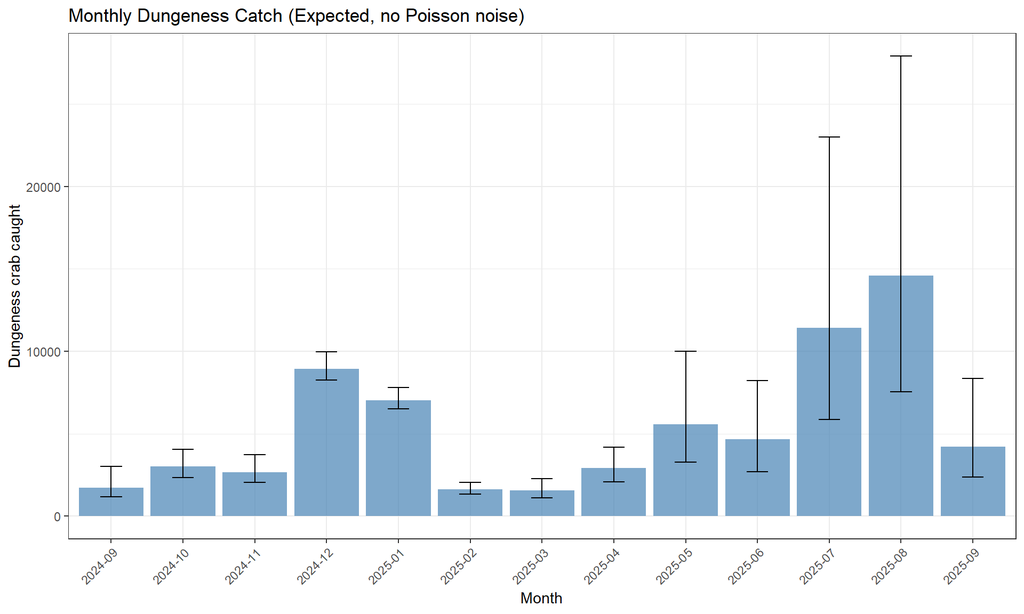

Monthly Dungeness catch with 95% intervals.

### 8.1 Monthly catch by crabbing mode

The monthly trajectory split by mode (shore, private boat, commercial/charter). The uncertainty source matches the method selected for each component, so the boat interval here is a lower bound when the boat is on PE.

```r
# 7.8b MONTHLY ESTIMATES BY CRABBING MODE (with per-mode uncertainty)
# ===========================================================================
# Companion to plot_monthly_catch.png. Breaks the monthly Dungeness catch out by
# crabbing mode, each month with a 95% interval. The uncertainty source matches
# the method actually selected for each component (convergence_report / pe_vs_bss):
#   Shore  (BSS, both sub-seasons): full posterior. Monthly catch draws are summed
#          from the daily C_expected draws, then 2.5/50/97.5 quantiles.
#   Private Boat: method is per sub-season (v7.0 scale-aware gate, B1.8). On the
#          2024-25 data the all-gear sub-season passes the gate and uses the BSS
#          posterior (full daily C_expected draws, CV ~27%), while the pot-closure
#          sub-season has too few interviews (< bss_min_interviews) and uses PE.
#          The PE branch distributes the selected PE point across months by monthly
#          effort share, then applies a design-based relative SE (stratified effort
#          SE / effort total) as ONE per-component lognormal scale shared across
#          months, so the monthly catches move together and the boat total carries
#          that relative SE. NOTE: the PE branch captures effort sampling
#          uncertainty but NOT CPUE sampling uncertainty, so a PE sub-season's
#          interval is a lower bound; the BSS posterior is the fuller
#          characterization. Branch selection is driven by bss_use_pe_for(), so if a
#          component's gate verdict changes in a future run this block follows it
#          automatically.
#   Commercial/Charter (census): point distributed by sampled-harvest share with
#          a catch-per-vessel sampling CV as the relative SE (small, high coverage).
# Fix 2 (v7.0): the PE monthly effort share is now population-aware (see the PE
# branch below). The boat uses the flat 24 h gear-hours run_pe_pooled() uses; shore keeps
# crabber-hours * day_length. This removes the prior day_length over-weighting of
# long-day summer months in the boat monthly distribution (totals were, and remain,
# unaffected; only the across-month split changed). The same formula lives in 7.8;
# the two PE-share blocks are still duplicated (with a minor na.rm difference) and
# are a candidate for consolidation into one helper in a future pass.
cat("\n", strrep("=",60), "\n MONTHLY ESTIMATES BY MODE\n", strrep("=",60), "\n")

modes_lvl <- c("Shore", "Private Boat", "Commercial/Charter")
mk_mat <- function() matrix(0, nrow = n_draws_max, ncol = length(all_months),
                            dimnames = list(NULL, all_months))
bymode_C <- setNames(lapply(modes_lvl, function(x) mk_mat()), modes_lvl)

# lognormal scale, mean 1, target relative SE (mean-preserving)
rln_scale <- function(n, rel_se) {
  rel_se <- max(rel_se, 1e-4)
  sdlog  <- sqrt(log(1 + rel_se^2))
  exp(stats::rnorm(n, -sdlog^2 / 2, sdlog))
}

for(cg in bss_catch_groups) {
  for(pop in c("shore","private_boat")) {
    mode_nm <- if(pop == "shore") "Shore" else "Private Boat"
    for(ss in subseasons) {
      label    <- paste0(pop, "_", ss$name, "_", cg)
      pe_label <- paste0(pop, "_", ss$name)
      b <- bss_all[[label]]

      days_ss <- prep_days_crab(ss$start, ss$end, params, L_eff_model = L_eff_model)
      days_ss$month_label <- format(days_ss$event_date, "%Y-%m")

      if(bss_use_pe_for(b)) {   # B1.8: PE if insufficient data OR failed scale-aware gate
        summ_ss <- prep_population_summary(dwg, pop, ss$start, ss$end, params)
        # Fix 2 (v7.0), POOL-3 (v7.6): population-aware daily effort, identical
        # rationale to 7.8. Boat uses the gear-DEPLOYMENT scale
        # (mean_count * gear_per_group * tau_boat); shore keeps crabber-hours
        # (mean_count * crabbers_per_gear * day_length). Share is normalized so
        # totals are unaffected; only the monthly split changes.
        # T4.4: shared monthly effort-share helper (03_R_functions/pe_monthly_effort_share.R).
        monthly_pe <- pe_monthly_effort_share(pop, summ_ss, days_ss, params)

        pe_catch_total <- pe_all[[pe_label]][[cg]] %||% 0
        eff_total <- pe_all[[pe_label]]$effort_total %||% NA_real_
        eff_se    <- pe_all[[pe_label]]$effort_se %||% NA_real_
        rel_se <- if(!is.na(eff_total) && eff_total > 0 && !is.na(eff_se) && eff_se > 0)
                    eff_se / eff_total else 0.30
        scale_draws <- rln_scale(n_draws_max, rel_se)   # common effort-level uncertainty

        for(m in monthly_pe$month_label) {
          if(m %in% all_months) {
            sh <- monthly_pe$share[monthly_pe$month_label == m]
            bymode_C[[mode_nm]][, m] <- bymode_C[[mode_nm]][, m] + (pe_catch_total * sh) * scale_draws
          }
        }
      } else {
        C_exp_bss   <- rstan::extract(b$fit, "C_expected")$C_expected
        n_fit_draws <- dim(C_exp_bss)[1]
        C_daily_mat <- C_exp_bss[,1,,1]
        for(m in unique(days_ss$month_label)) {
          day_idx <- which(days_ss$month_label == m)
          if(length(day_idx) == 0 || !(m %in% all_months)) next
          month_C <- if(length(day_idx)==1) C_daily_mat[, day_idx] else rowSums(C_daily_mat[, day_idx])
          idx <- rep_len(1:n_fit_draws, n_draws_max)
          bymode_C[[mode_nm]][, m] <- bymode_C[[mode_nm]][, m] + month_C[idx]
        }
      }
    }
  }
}

# Commercial/charter (census): distribute by sampled-harvest share, with a
# catch-per-vessel sampling CV as the relative SE (robust fallback if unavailable).
if(!is.null(pe_all$comm_charter$daily_est)) {
  comm_daily    <- pe_all$comm_charter$daily_est |> mutate(month_label = format(date, "%Y-%m"))
  comm_total    <- pe_all$comm_charter$Dungeness_Kept %||% 0
  total_sampled <- sum(comm_daily$est_dung)
  rel_se_comm <- tryCatch({
    cpv <- dwg$interview |> filter(population == "comm_charter") |> pull(dungeness_kept)
    cpv <- cpv[is.finite(cpv)]
    if(length(cpv) > 1 && mean(cpv) > 0) (sd(cpv) / sqrt(length(cpv))) / mean(cpv) else 0.12
  }, error = function(e) 0.12)
  scale_comm <- rln_scale(n_draws_max, rel_se_comm)
  if(total_sampled > 0) {
    for(m in unique(comm_daily$month_label)) {
      if(m %in% all_months) {
        sh <- sum(comm_daily$est_dung[comm_daily$month_label == m]) / total_sampled
        bymode_C[["Commercial/Charter"]][, m] <- bymode_C[["Commercial/Charter"]][, m] + (comm_total * sh) * scale_comm
      }
    }
  }
}

monthly_bymode <- purrr::map_dfr(modes_lvl, function(md) {
  M <- bymode_C[[md]]
  tibble(
    Mode   = md,
    Month  = all_months,
    median = apply(M, 2, median),
    lo95   = apply(M, 2, quantile, probs = 0.025),
    hi95   = apply(M, 2, quantile, probs = 0.975)
  )
}) |>
  mutate(Mode  = factor(Mode, levels = modes_lvl),
         Month = factor(Month, levels = all_months),
         across(c(median, lo95, hi95), round))

print(monthly_bymode, n = nrow(monthly_bymode))
write.csv(monthly_bymode, file.path(output_dir, "monthly_estimates_by_mode.csv"), row.names = FALSE)

mode_cols <- c("Shore" = "#2c7fb8", "Private Boat" = "#d95f0e", "Commercial/Charter" = "#31a354")

# (1) Grouped (dodged) bars, one colour per mode, with 95% interval error bars.
p_bymode_dodge <- monthly_bymode |>
  ggplot(aes(x = Month, y = median, fill = Mode)) +
  geom_col(position = position_dodge(width = 0.8), width = 0.75, alpha = 0.85) +
  geom_errorbar(aes(ymin = lo95, ymax = hi95),
                position = position_dodge(width = 0.8), width = 0.3) +
  scale_fill_manual(values = mode_cols) +
  labs(title = "Monthly Dungeness Catch by Crabbing Mode",
       subtitle = "Median with 95% interval. Shore: BSS posterior. Private Boat: BSS posterior (all-gear), PE point with design-based effort SE (pot closure). Commercial/Charter: census, catch-per-vessel CV.",
       x = "Month", y = "Dungeness crab caught", fill = "Mode") +
  theme_bw() +
  theme(axis.text.x = element_text(angle = 45, hjust = 1), legend.position = "top")
ggsave(file.path(output_dir, "plot_monthly_catch_by_mode.png"), p_bymode_dodge, width = 13, height = 6)

# (2) Faceted companion (free y) so shore and commercial panels stay readable
# next to the larger boat panel.
p_bymode_facet <- monthly_bymode |>
  ggplot(aes(x = Month, y = median, fill = Mode)) +
  geom_col(width = 0.7, alpha = 0.85) +
  geom_errorbar(aes(ymin = lo95, ymax = hi95), width = 0.3) +
  scale_fill_manual(values = mode_cols) +
  facet_wrap(~Mode, ncol = 1, scales = "free_y") +
  labs(title = "Monthly Dungeness Catch by Crabbing Mode",
       subtitle = "Median with 95% interval (free y-axis per panel)",
       x = "Month", y = "Dungeness crab caught") +
  theme_bw() +
  theme(axis.text.x = element_text(angle = 45, hjust = 1), legend.position = "none")
ggsave(file.path(output_dir, "plot_monthly_catch_by_mode_facet.png"), p_bymode_facet, width = 12, height = 9)


# ===========================================================================
```

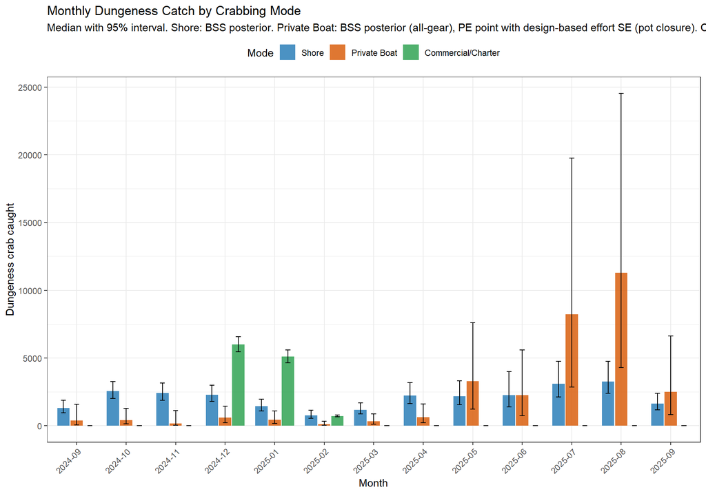

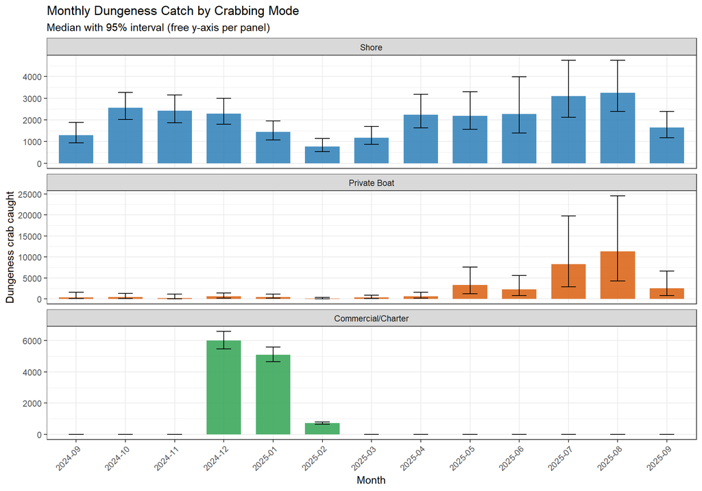

```r
for (nm in c('p_bymode_dodge','p_bymode_facet')) if (exists(nm)) print(get(nm))
```

## 9. Catch by crabbing mode

Total season catch attributed to each crabbing mode.

```r
# 7.9 CATCH BY CRABBING MODE
# ===========================================================================

cat("\n", strrep("=",60), "\n CATCH BY CRABBING MODE\n", strrep("=",60), "\n")

mode_table <- tibble(
  Mode = c("Shore (Dock/Jetty/Beach)", "Private Boat", "Commercial/Charter", "PORT TOTAL"),
  PE_Catch = c(
    pe_pop_sum("shore", "Dungeness_Kept"),
    pe_pop_sum("private_boat", "Dungeness_Kept"),
    pe_field("comm_charter", "Dungeness_Kept"), NA
  ),
  PE_Effort = c(
    pe_pop_sum("shore", "effort_total"),
    pe_pop_sum("private_boat", "effort_total"),
    pe_field("comm_charter", "effort_total"), NA
  )
)
mode_table$PE_Catch[4] <- sum(mode_table$PE_Catch[1:3], na.rm = TRUE)
mode_table$PE_Effort[4] <- sum(mode_table$PE_Effort[1:3], na.rm = TRUE)
print(mode_table |> mutate(across(where(is.numeric), round)))
write.csv(mode_table, file.path(output_dir, "catch_by_mode.csv"), row.names = FALSE)


# ===========================================================================
```

```r
report_table(mode_table, 'Season catch by crabbing mode.')
```

Season catch by crabbing mode.

| Mode | PE_Catch | PE_Effort |
| --- | --- | --- |
| Shore (Dock/Jetty/Beach) | 21,714.27 | 23,523.99 |
| Private Boat | 11,569.93 | 3,888.96 |
| Commercial/Charter | 11,821.13 | 278.55 |
| PORT TOTAL | 45,105.33 | 27,691.49 |

### 9.1 Catch by gear type

In the pooled model, gear-type catch is derived after estimation by allocating each population’s total over gear types using the interview gear-catch shares. As of the 2026-07-13 change (item 3 / T2.2) this allocation propagates uncertainty from both sources: the gear shares are drawn from a Dirichlet posterior (`pi ~ Dirichlet(observed gear catch + 0.5)`) and multiplied by the population total’s BSS posterior draws, so each gear carries a 95% credible interval rather than a point. It is still an allocation of the pooled total, not an independently modeled per-gear CPUE process (that is the gear-resolved model’s role), but its uncertainty is now honest.

```r
# 7.10 CATCH BY GEAR TYPE (Dirichlet pi_gear + BSS total propagation; item 3)
#
# Pooled model: uses interview data to estimate the proportion of catch
# by primary gear type, then applies to combined catch estimates.
# ===========================================================================

cat("\n", strrep("=",60), "\n CATCH BY GEAR TYPE (proportional)\n", strrep("=",60), "\n")

gear_catch <- dwg$interview |>
  filter(population %in% c("shore","private_boat"), dungeness_kept > 0) |>
  mutate(
    gear_primary = case_when(
      str_detect(gear_type, "(?i)^pot|, pot|pot,") & !str_detect(gear_type, "(?i)slip ring") ~ "Pot",
      str_detect(gear_type, "(?i)ring net")     ~ "Ring Net",
      str_detect(gear_type, "(?i)trap|star")    ~ "Trap",
      str_detect(gear_type, "(?i)snare")        ~ "Snare",
      TRUE                                      ~ "Other"
    )
  )

gear_props <- gear_catch |>
  group_by(population, gear_primary) |>
  summarise(total_catch = sum(dungeness_kept), n_int = n(), .groups = "drop") |>
  group_by(population) |>
  mutate(prop_catch = total_catch / sum(total_catch)) |>
  ungroup()

cat("\n  Observed catch proportions by gear type:\n")
print(gear_props |> select(population, gear_primary, n_int, total_catch, prop_catch) |>
        mutate(prop_catch = round(prop_catch, 3)))

total_shore_catch <- pe_pop_sum("shore", "Dungeness_Kept")
total_boat_catch <- pe_pop_sum("private_boat", "Dungeness_Kept")

# --- item 3 (T2.2 / B5, 2026-07-13): propagate pi_gear + total uncertainty -------------
# The old breakdown multiplied POINT interview gear-proportions by a POINT total (a double
# point estimate with no interval). It now propagates BOTH sources: (a) each population's
# gear shares as pi ~ Dirichlet(observed gear catch + 0.5), the multinomial-Dirichlet
# posterior for catch shares; (b) the population total as its BSS posterior draws (the
# summed C_expected draws of that population's fitted sub-seasons, plus the PE point for
# any PE-fallback sub-season). Per-gear catch = total_draw * pi_draw, summed over the two
# populations and the comm/charter census (all Pot), reported as median + 95% CI. NOTE:
# the gear-resolved model has no true Dirichlet either (its pi_gear scaffolding never
# reaches its Stan), so this R-side propagation is the correct fix for both tracks and
# could be back-ported. tryCatch falls back to the old point allocation if a draw object
# is unavailable, so the section can never break the knit.
gear_levels <- c("Pot", "Ring Net", "Trap", "Snare", "Other")

gear_pop_total_draws <- function(pop, n_target) {
  labs <- paste0(pop, "_", vapply(subseasons, function(z) z$name, ""), "_Dungeness_Kept")
  draws <- NULL; pe_add <- 0
  for (lab in labs) {
    b <- bss_all[[lab]]
    if (!is.null(b) && !isTRUE(b$pe_fallback) && !is.null(b$C_exp_draws)) {
      d <- as.numeric(b$C_exp_draws)
      if (is.null(draws)) draws <- d
      else { k <- min(length(draws), length(d)); draws <- draws[seq_len(k)] + d[seq_len(k)] }
    } else {
      pe_add <- pe_add + (pe_all[[sub("_Dungeness_Kept$", "", lab)]]$Dungeness_Kept %||% 0)
    }
  }
  if (is.null(draws)) return(rep(pe_add, n_target))
  draws <- draws + pe_add
  if (length(draws) >= n_target) draws[seq_len(n_target)] else sample(draws, n_target, replace = TRUE)
}

gear_summary <- tryCatch({
  set.seed(params$bss_seed)
  n_gd <- 4000
  rdir <- function(n, alpha) {  # n x length(alpha) Dirichlet draws via gamma normalization
    g <- matrix(rgamma(n * length(alpha), shape = rep(alpha, each = n), rate = 1), nrow = n)
    g / rowSums(g)
  }
  per_gear <- matrix(0, n_gd, length(gear_levels), dimnames = list(NULL, gear_levels))
  for (pop in c("shore", "private_boat")) {
    gc <- gear_props |> dplyr::filter(population == pop)
    counts <- setNames(rep(0, length(gear_levels)), gear_levels)
    if (nrow(gc) > 0) counts[as.character(gc$gear_primary)] <- gc$total_catch
    per_gear <- per_gear + rdir(n_gd, counts + 0.5) * gear_pop_total_draws(pop, n_gd)
  }
  per_gear[, "Pot"] <- per_gear[, "Pot"] + (pe_all$comm_charter$Dungeness_Kept %||% 0)
  tibble(
    gear_primary = gear_levels,
    PE_Catch = round(apply(per_gear, 2, median)),
    lo95     = round(apply(per_gear, 2, quantile, 0.025)),
    hi95     = round(apply(per_gear, 2, quantile, 0.975))
  ) |>
    dplyr::mutate(Proportion = round(PE_Catch / sum(PE_Catch), 3)) |>
    dplyr::arrange(dplyr::desc(PE_Catch))
}, error = function(e) {
  cat(sprintf("  Gear Dirichlet propagation failed (%s); using point allocation.\n", conditionMessage(e)))
  ge <- gear_props |>
    mutate(pop_total = dplyr::case_when(population == "shore" ~ total_shore_catch,
                                        population == "private_boat" ~ total_boat_catch),
           est_catch = round(pop_total * prop_catch)) |>
    dplyr::select(gear_primary, est_catch)
  ge <- bind_rows(ge, tibble(gear_primary = "Pot",
                             est_catch = round(pe_all$comm_charter$Dungeness_Kept %||% 0)))
  ge |> group_by(gear_primary) |>
    summarise(PE_Catch = sum(est_catch), .groups = "drop") |>
    mutate(lo95 = NA_real_, hi95 = NA_real_, Proportion = round(PE_Catch / sum(PE_Catch), 3)) |>
    arrange(desc(PE_Catch))
})

cat("\n--- Catch by Gear Type (Dirichlet pi_gear + BSS-total propagation) ---\n")
print(gear_summary)
write.csv(gear_summary, file.path(output_dir, "catch_by_gear_type.csv"), row.names = FALSE)

p_gear <- gear_summary |>
  mutate(gear_primary = fct_reorder(gear_primary, PE_Catch)) |>
  ggplot(aes(x = gear_primary, y = PE_Catch, fill = gear_primary)) +
  geom_col() +
  geom_errorbar(aes(ymin = lo95, ymax = hi95), width = 0.2, na.rm = TRUE) +
  geom_text(aes(label = sprintf("%s (%.0f%%)", format(PE_Catch, big.mark=","), Proportion*100)),
            hjust = -0.1, size = 3) +
  labs(title = "Estimated Dungeness Catch by Gear Type (Dirichlet pi_gear + BSS total)",
       x = "Gear Type", y = "Estimated Catch (median, 95% CI)") +
  theme_bw() + theme(legend.position = "none") + coord_flip()
ggsave(file.path(output_dir, "plot_catch_by_gear_type.png"), p_gear, width = 10, height = 6)
```

Season catch by gear type: Dirichlet-propagated interview gear-shares times BSS population-total draws (median, 95% CI). An NA interval marks the point-allocation fallback.

| gear_primary | PE_Catch | lo95 | hi95 | Proportion |
| --- | --- | --- | --- | --- |
| Pot | 48,135 | 31,113 | 75,145 | 0.68 |
| Trap | 11,494 | 10,220 | 13,061 | 0.16 |
| Ring Net | 9,404 | 7,674 | 11,911 | 0.13 |
| Snare | 1,959 | 1,684 | 2,299 | 0.03 |
| Other | 288 | 124 | 623 | 0.00 |

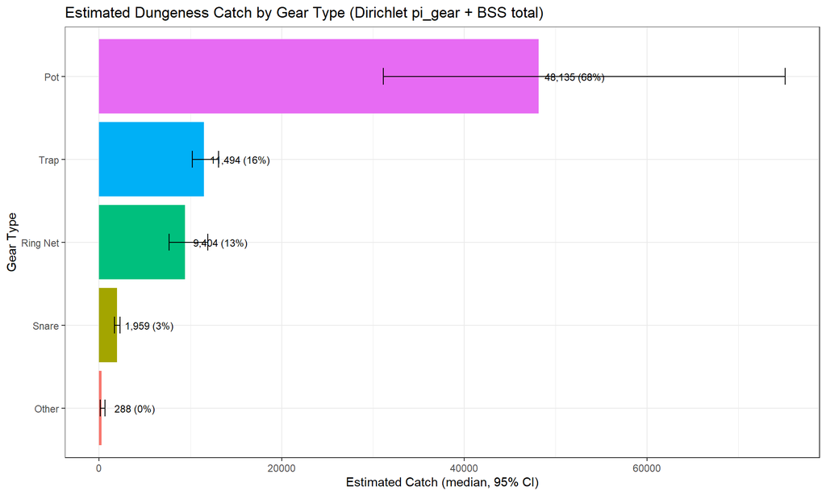

Catch by gear type.

```r
report_table(gear_summary, 'Season catch by gear type: Dirichlet-propagated interview gear-shares times BSS population-total draws (median, 95% CI). An NA interval marks the point-allocation fallback.'); if (exists('p_gear')) print(p_gear)
```

## 10. Convergence report

The per-fit diagnostic table behind the gate decision: R-hat and effective sample size for the summed effort and catch, the divergent fraction, and the pass/fail flag. **Healthy:** `pass_convergence` TRUE with R-hat near 1.00 and effective sample size well above 400 on every fit that had sufficient data.

```r
# ---- 7.11 CONVERGENCE REPORT ----
# v7.0 (B1.8): the pass/fail decision and every diagnostic column are computed once
# in 7.6b (bss_compute_gate) and stored as bss_all[[label]]$gate_info, so this section
# is now pure assembly. This guarantees the report agrees with the method actually
# used in the totals (7.7/7.8/7.8b consume the same use_bss flag). All gate
# warnings were already emitted in 7.6b at fit time. Columns now include the
# scale-aware impact (impact_C_sd, impact_E_sd; the gating criterion) and retain
# the legacy level-distortion (distortion_C, distortion_E) as reported-only.
cat("\n", strrep("=",60), "\n CONVERGENCE REPORT\n", strrep("=",60), "\n")

convergence_df <- bind_rows(lapply(names(bss_all), function(label) bss_all[[label]]$gate_info))
print(convergence_df)
write.csv(convergence_df, file.path(output_dir, "convergence_report.csv"), row.names = FALSE)
```

```r
# Curated, HTML-friendly view of the convergence report: short fit labels and the key
# gate columns only. The full ~20-column table (treedepth, level-distortion, and the
# per-criterion pass flags) is written to convergence_report.csv.
conv_disp <- tryCatch(
  dplyr::transmute(convergence_df,
    Fit             = short_fit(fit),
    AR              = ar_resolution,
    Div             = divergences,
    `Div frac`      = round(divergence_fraction, 3),
    `R-hat C`       = round(C_sum_rhat, 3),
    `R-hat E`       = round(E_sum_rhat, 3),
    `min n_eff`     = pmin(C_sum_neff, E_sum_neff),
    `Impact C (SD)` = round(impact_C_sd, 3),
    `Impact E (SD)` = round(impact_E_sd, 3),
    Pass            = pass_convergence,
    Method          = method_selected),
  error = function(e) convergence_df)
report_table(conv_disp,
  paste("Per-fit convergence summary (key gate columns; full detail in",
        "convergence_report.csv). Div frac is the divergent-transition fraction (backstop",
        "0.05); Impact C/E (SD) is the scale-aware gating criterion (threshold 0.10);",
        "Method is what the totals actually use. Healthy: R-hat near 1.00, min n_eff",
        "above 400, Pass = TRUE."),
  digits = 3)
```

Per-fit convergence summary (key gate columns; full detail in convergence_report.csv). Div frac is the divergent-transition fraction (backstop 0.05); Impact C/E (SD) is the scale-aware gating criterion (threshold 0.10); Method is what the totals actually use. Healthy: R-hat near 1.00, min n_eff above 400, Pass = TRUE.

| Fit | AR | Div | Div frac | R-hat C | R-hat E | min n_eff | Impact C (SD) | Impact E (SD) | Pass | Method |
| --- | --- | --- | --- | --- | --- | --- | --- | --- | --- | --- |
| shore pot-closure | biweekly | 119 | 0.020 | 1 | 1 | 6,161 | 0.000 | 0.002 | TRUE | BSS |
| shore all-gear | daily | 468 | 0.047 | 1 | 1 | 6,582 | 0.000 | 0.001 | TRUE | BSS |
| boat pot-closure | monthly | 32 | 0.005 | 1 | 1 | 4,839 | 0.001 | 0.000 | TRUE | BSS |
| boat all-gear | monthly | 39 | 0.004 | 1 | 1 | 15,381 | 0.001 | 0.000 | TRUE | BSS |

### 10.1 Per-fit BSS plots

Per-component season-total posterior densities (C_sum, E_sum), the BSS daily effort ribbon, and the BSS daily expected-catch ribbon, one set per fitted component. Each is also saved as a PNG in the run folder.

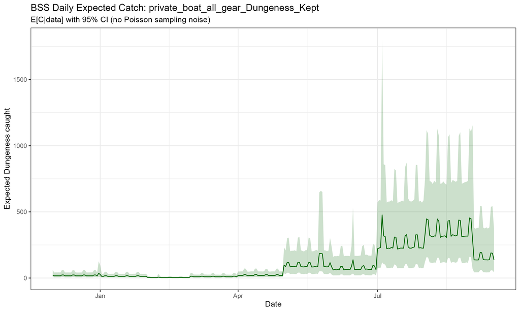

Per-fit BSS effort, catch, and posterior-density plots (one set per fitted component).

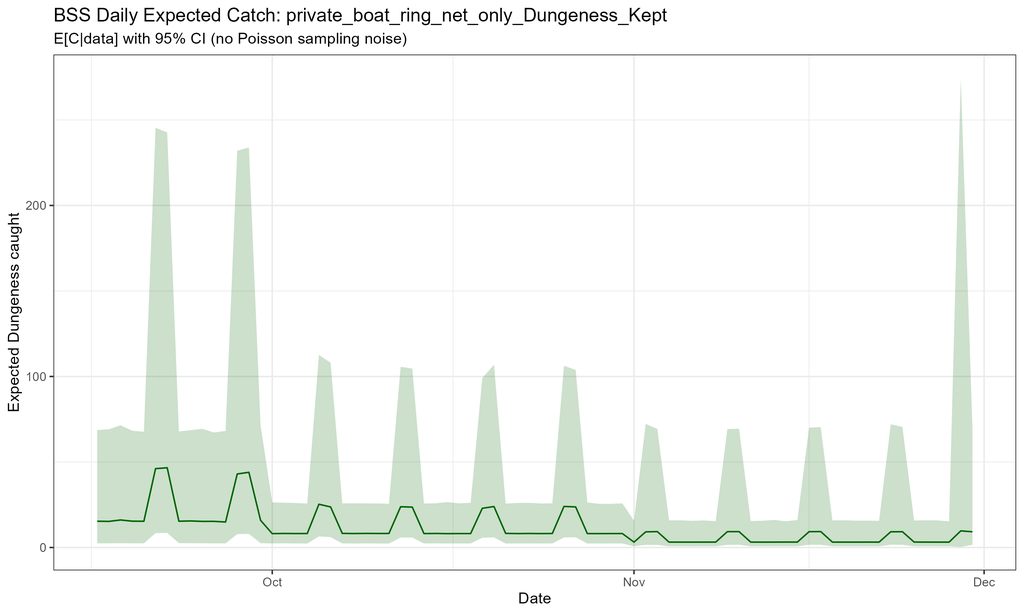

Per-fit BSS effort, catch, and posterior-density plots (one set per fitted component).

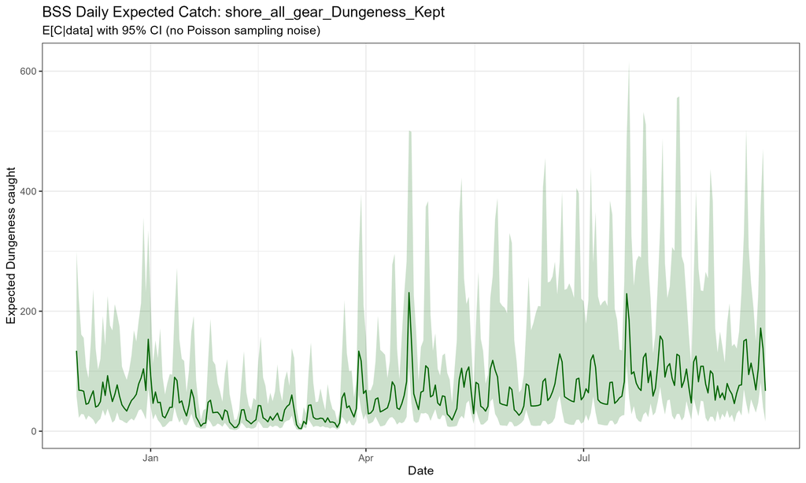

Per-fit BSS effort, catch, and posterior-density plots (one set per fitted component).

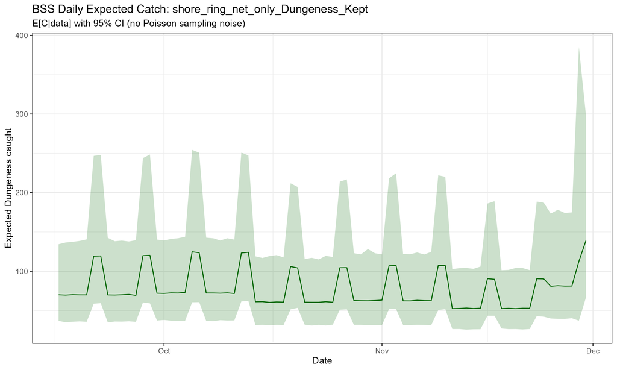

Per-fit BSS effort, catch, and posterior-density plots (one set per fitted component).

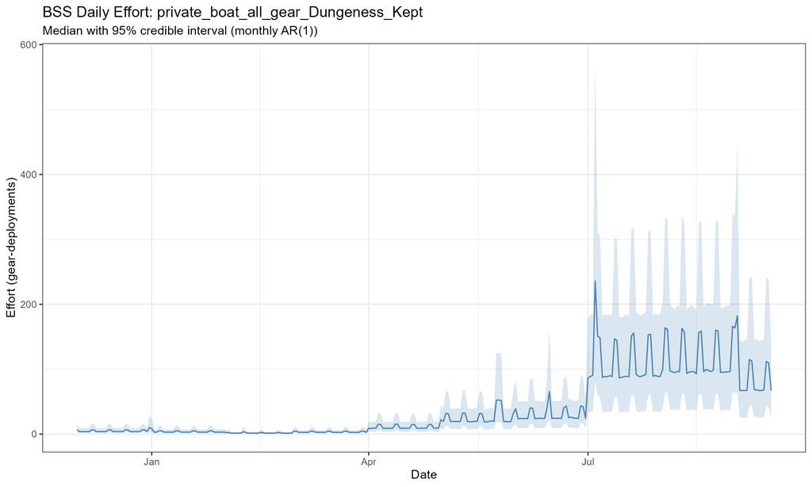

Per-fit BSS effort, catch, and posterior-density plots (one set per fitted component).

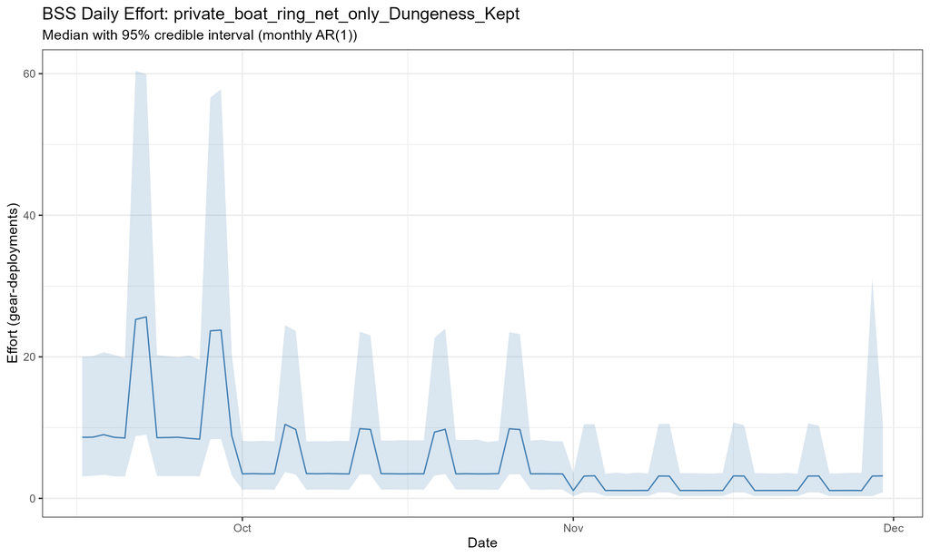

Per-fit BSS effort, catch, and posterior-density plots (one set per fitted component).

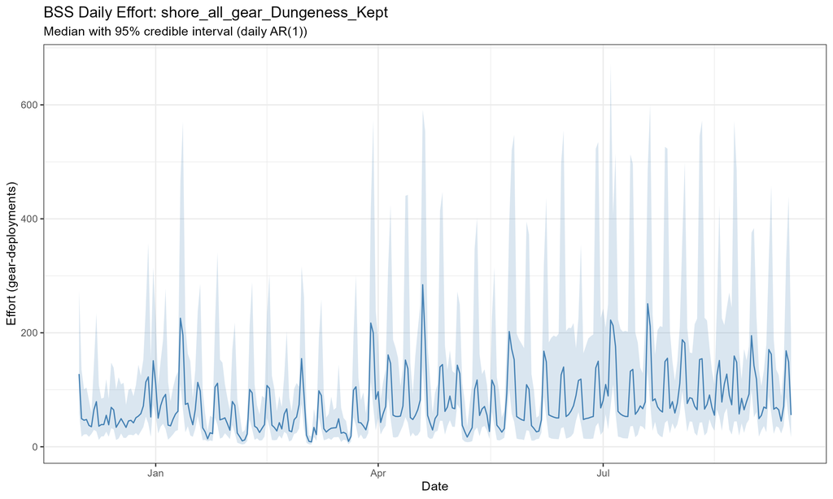

Per-fit BSS effort, catch, and posterior-density plots (one set per fitted component).

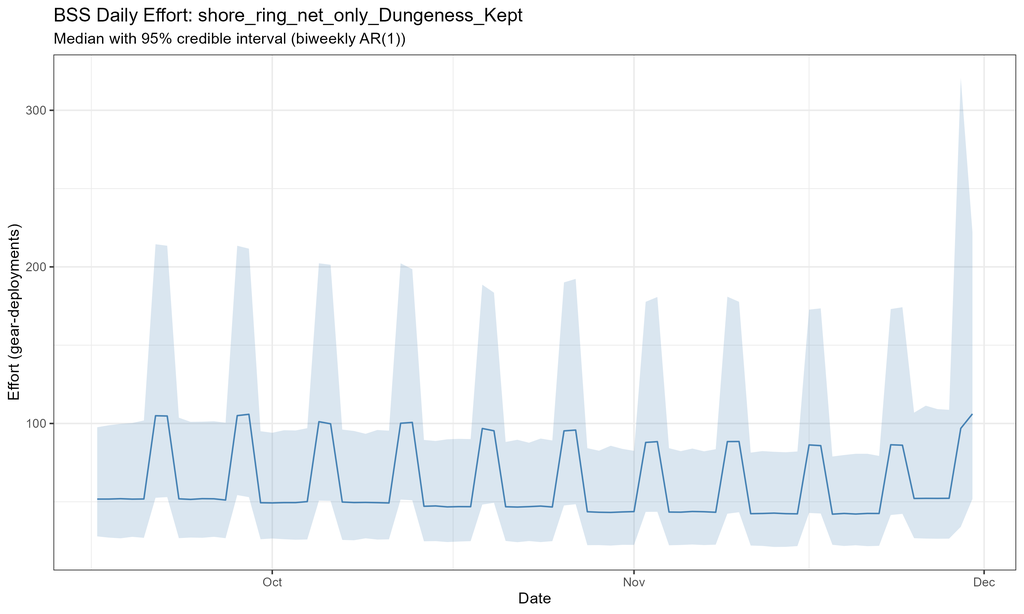

Per-fit BSS effort, catch, and posterior-density plots (one set per fitted component).

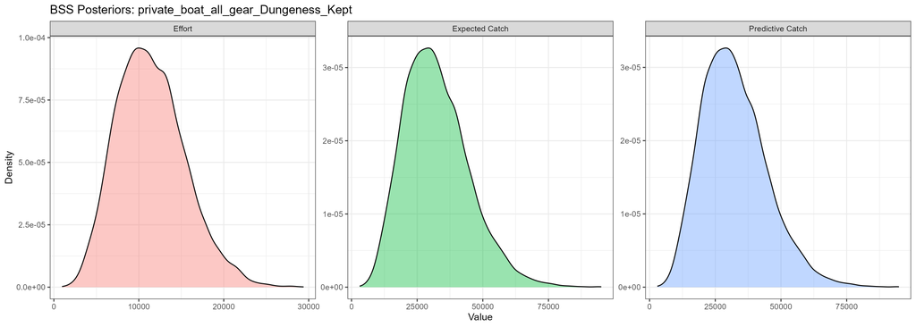

Per-fit BSS effort, catch, and posterior-density plots (one set per fitted component).

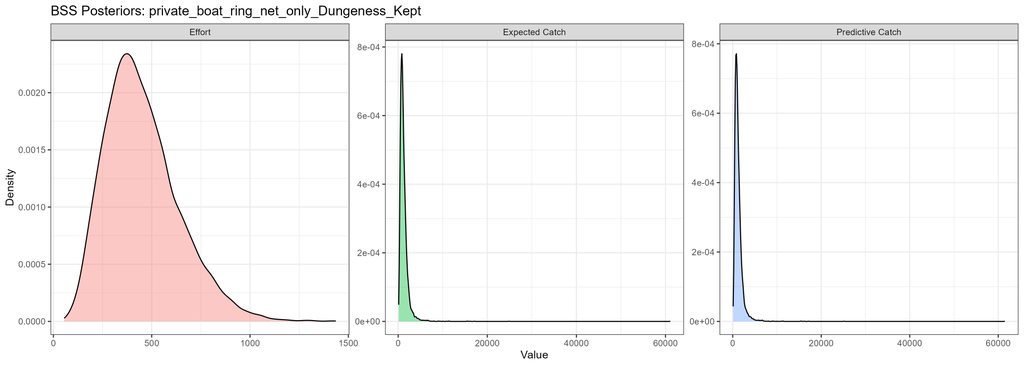

Per-fit BSS effort, catch, and posterior-density plots (one set per fitted component).

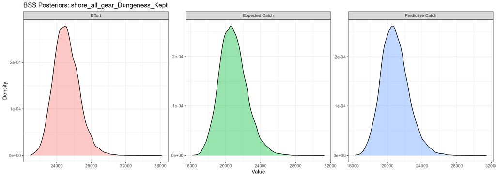

Per-fit BSS effort, catch, and posterior-density plots (one set per fitted component).

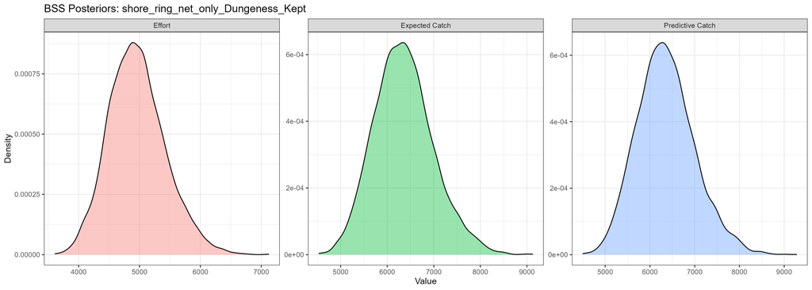

Per-fit BSS effort, catch, and posterior-density plots (one set per fitted component).

## 11. Model diagnostics

Per-fit diagnostics are written to the run folder: structural-parameter summaries, divergence localization, and posterior-predictive calibration (PPC/PIT). **Healthy:** PPC coverage near nominal (about 0.95 at the 95 percent level) and PIT means near 0.5. These files are the deeper check behind the gate.

```r
# ---- 7.12 PER-FIT MODEL DIAGNOSTICS (B1.6) ----
# Additive per-fit diagnostics: structural parameters, divergence localization,
# and posterior predictive calibration. write_bss_diagnostics() is sourced from
# 03_R_functions/model_diagnostics.R and is fully tryCatch-wrapped, so a diagnostic
# failure prints a note and never interrupts the run. Storing bss_data with each
# fit (Section 7) is what enables the PPC; without it the PPC is skipped cleanly.
cat("\n", strrep("=",60), "\n MODEL DIAGNOSTICS\n", strrep("=",60), "\n")
for(label in names(bss_all)) {
  b <- bss_all[[label]]
  if(is.null(b$fit)) next                  # PE-only entry: nothing to diagnose
  cat(sprintf("  %s:\n", label))
  # 2026-08-30: the gate verdict travels INTO the per-fit tables, so a parameter row lifted
  # out of a rejected fit's file carries that fact with it.
  write_bss_diagnostics(b$fit,
                        if(!is.null(b$bss_data)) b$bss_data else NULL,
                        label, output_dir,
                        fit_method = b$gate_info$method_selected %||%
                          (if (isTRUE(b$use_bss)) "BSS" else "PE (convergence fail)"))
  # 2026-09-04: persist the draws the PPC is computed from. Three separate defects in the
  # diagnostic arithmetic have each cost a full multi-hour re-fit to correct, most recently
  # the ZINB catch stream being scored as NB2. See 03_R_functions/save_bss_ppc_draws.R.
  if (isTRUE(params$save_ppc_draws) && !is.null(b$bss_data))
    save_bss_ppc_draws(b$fit, b$bss_data, label, output_dir,
                       max_draws = params$save_ppc_draws_max %||% NULL)
}
```

Posterior-predictive calibration by fit and data stream. Healthy: Cover 95% near 0.95 and PIT mean near 0.50; coverage well above nominal means the predictive is too wide (over-dispersed), the effort streams are the known case.

| Fit | Stream | Cover 50% | Cover 95% | PIT mean | PIT sd | n |
| --- | --- | --- | --- | --- | --- | --- |
| boat all-gear | trailer | 0.52 | 0.98 | 0.48 | 0.27 | 195 |
| boat all-gear | osp | 0.48 | 0.98 | 0.52 | 0.28 | 130 |
| boat all-gear | catch | 0.59 | 0.95 | 0.51 | 0.27 | 131 |
| boat pot-closure | trailer | 0.61 | 1.00 | 0.47 | 0.27 | 44 |
| boat pot-closure | osp | 0.61 | 0.94 | 0.57 | 0.26 | 18 |
| boat pot-closure | catch | 0.47 | 1.00 | 0.53 | 0.29 | 17 |
| shore all-gear | gear | 0.70 | 0.98 | 0.50 | 0.23 | 311 |
| shore all-gear | catch | 0.46 | 0.99 | 0.50 | 0.27 | 1,649 |
| shore pot-closure | gear | 0.58 | 0.98 | 0.52 | 0.27 | 52 |
| shore pot-closure | catch | 0.44 | 0.98 | 0.50 | 0.29 | 627 |

### 11.1 Effort over-dispersion decomposition

Splits each effort-count predictive variance into its Poisson floor, negative-binomial observation over-dispersion, and latent-process parts, written per fit. It identifies which lever drives any excess effort variance before a prior or model change is considered.

```r
# ---- 7.13 EFFORT OVER-DISPERSION DECOMPOSITION (T1.5) ----
# Additive per-fit diagnostic. The v7.0 PPC showed the negative-binomial
# effort model is over-dispersed (gear/trailer PIT central humps, coverage_50
# ~ 0.63-0.75 vs the nominal 0.50); that says the effort predictive is too
# wide but not which part of the model to tune. This decomposes each effort-
# count predictive variance, by the law of total variance, into its Poisson
# floor E[mu], the NB observation over-dispersion E[mu^2/r_E] (the r_E /
# sigma_r_E lever), and the latent process variance Var(mu) (the sigma_eps_E /
# single-cell level lever), and reports their shares so the lever is identified
# before any prior or model change. write_effort_overdispersion_diag() is
# sourced from 03_R_functions/diagnose_effort_overdispersion.R and is fully
# tryCatch-wrapped; it writes only CSVs (effort_overdispersion_decomp_<label>
# and ..._byobs_<label>) and changes nothing in the model. It needs the in-
# memory fit and its bss_data (stored with each fit in Section 7), which is why
# it runs here in the fit session rather than from the saved summary CSVs.
cat("\n", strrep("=",60), "\n EFFORT OVER-DISPERSION DECOMPOSITION (T1.5)\n", strrep("=",60), "\n")
for(label in names(bss_all)) {
  b <- bss_all[[label]]
  if(is.null(b$fit)) next                  # PE-only entry: nothing to decompose
  write_effort_overdispersion_diag(b$fit,
                                   if(!is.null(b$bss_data)) b$bss_data else NULL,
                                   label, output_dir)
}
```

Effort-count predictive variance decomposition (shares sum to 1): Poisson floor, negative-binomial observation over-dispersion, and latent AR-process variance. The dominant share is the lever to tune if the effort predictive is too wide.

| Fit | Stream | Poisson | NB overdisp | Latent AR | Cover 50% |
| --- | --- | --- | --- | --- | --- |
| boat all-gear | trailer | 0.03 | 0.93 | 0.04 | 0.52 |
| boat pot-closure | trailer | 0.15 | 0.77 | 0.08 | 0.61 |
| shore all-gear | gear | 0.15 | 0.58 | 0.27 | 0.70 |
| shore pot-closure | gear | 0.07 | 0.80 | 0.13 | 0.58 |

### 11.2 Extended per-fit outputs and PSIS-LOO

The extended output series (parameter posteriors, AR paths, coverage maps, PPC residuals, sampler diagnostics, prior-vs-posterior tables) and PSIS-LOO cross-validation are written to the run folder for later analysis; nothing here changes an estimate.

```r
# ---- 7.13b EXTENDED RUN OUTPUTS (O1-O11) ----
# Additive persistence of in-memory quantities not previously saved, so the R
# workspace is rarely needed for later diagnosis. Per-fit (O1-O6, O8, O9): full
# parameter posterior summary, AR latent path, AR-period data coverage, modeled
# daily CPUE, per-observation PPC residuals (exact randomized PIT), HMC sampler
# diagnostics (E-BFMI), summed-quantity draws, prior-vs-posterior. Run-level (O7,
# O10, O11): monthly PE-vs-BSS by mode, gear proportions, per-fit data summary.
# Sourced from 03_R_functions/save_run_diagnostics.R; every writer is tryCatch-
# wrapped and writes only CSVs, so this changes no estimate. The fit objects
# (O12) are deliberately not saved, to avoid output/ bloat.
cat("\n", strrep("=",60), "\n EXTENDED RUN OUTPUTS (O1-O11)\n", strrep("=",60), "\n")
for(label in names(bss_all)) {
  b <- bss_all[[label]]
  if(is.null(b$fit)) next                  # PE-only entry: nothing to extract
  # 2026-08-27: pass the run seed so the diagnostic draw subsampling is reproducible
  # (see the note in save_run_diagnostics.R; the port total stays RNG-sensitive regardless).
  write_fit_extended_diagnostics(b$fit, b$bss_data, b$days_ss, label, output_dir,
                                 seed = params$bss_seed %||% 1L)
  write_loo_diagnostics(b$fit, b$bss_data, b$days_ss, label, output_dir)
  # POOL-5: CPUE estimator triad, saturation exponent, effort-linearity, and the
  # E/h unit assertion (03_R_functions/bss_cpue_diagnostics.R). Diagnostic-only:
  # writes cpue_estimators_/cpue_saturation_/cpue_linearity_<label>.csv and changes
  # no estimate. This is the check that surfaces a boat/shore effort-unit defect
  # (e.g. catch flat in soak time) the same way it did for gear-resolved. Wrapped
  # so a diagnostic error (or the unit assertion) can never abort the run.
  tryCatch(write_cpue_diagnostics(b, label, output_dir),
           error = function(e)
             cat(sprintf("  CPUE diagnostics skipped for %s: %s\n", label, conditionMessage(e))))
}
write_run_level_diagnostics(bss_all, pe_all,
                            if(exists("gear_props")) gear_props else NULL,
                            params, output_dir)
# improvement-plan item 5.5 (2026-08-30): model ADEQUACY, reported beside the convergence
# gate rather than folded into it. The gate asks whether the sampler worked; this asks
# whether the model is carrying the data. It changes no selection. Runs after the per-fit
# LOO and PPC writers because it reads their output.
write_model_adequacy(bss_all, output_dir, params)
```

CPUE effort-unit validity. beta_h is the catch-vs-effort elasticity (harvest- unbiased when it covers 1, shown as ‘linear? = ok’); the model CPUE should track the design-based ratio-of-sums (RoS). ‘sat? = FLAG’ (catch sub-linear in soak time) is expected for pots and is the reason the unit is deployments, not hours.

| Fit | Unit | n | CPUE RoS | CPUE model | beta_h | linear? | sat beta | sat? |
| --- | --- | --- | --- | --- | --- | --- | --- | --- |
| boat all-gear | gear-deployments | 131 | 3.36 | 2.79 | 0.75 | ok | 0.25 | FLAG |
| boat pot-closure | gear-deployments | 17 | 2.29 | 2.40 | NA | - | NA | - |
| shore all-gear | gear-deployments | 1,649 | 0.87 | 0.83 | 1.05 | ok | 0.22 | FLAG |
| shore pot-closure | gear-deployments | 627 | 1.26 | 1.28 | 0.92 | ok | 0.27 | FLAG |

Per-fit data coverage: latent days, effort observations, interviews, and I/E observations, with the percent of days carrying any effort/interview data. Thin coverage is where the BSS leans hardest on the AR process and priors.

| Fit | Method | AR | Days | Eff obs | Interviews | I/E obs | % days eff | % days int |
| --- | --- | --- | --- | --- | --- | --- | --- | --- |
| shore pot-closure | BSS | biweekly | 76 | 52 | 627 | 0 | 68 | 67 |
| shore all-gear | BSS | daily | 289 | 311 | 1,649 | 4 | 50 | 50 |
| boat pot-closure | BSS | monthly | 76 | 44 | 17 | 0 | 57 | 17 |
| boat all-gear | BSS | monthly | 289 | 195 | 131 | 0 | 50 | 23 |

PSIS-LOO by data stream. p_loo is the effective number of parameters; a large ‘Pareto k>0.7’ count means LOO is unreliable for that stream (the model is near- saturated there), so read its elpd_loo with caution.

| Fit | Stream | n | elpd_loo | p_loo | Pareto k>0.7 |
| --- | --- | --- | --- | --- | --- |
| boat all-gear | trailer | 195 | -559.1 | 8.0 | 0 |
| boat all-gear | catch | 131 | -451.5 | 10.5 | 1 |
| boat pot-closure | trailer | 44 | -87.2 | 3.5 | 0 |
| boat pot-closure | catch | 17 | -52.8 | 3.6 | 1 |
| shore all-gear | gear | 311 | -1,249.1 | 106.9 | 26 |
| shore all-gear | catch | 1,649 | -3,147.8 | 55.5 | 0 |
| shore pot-closure | gear | 52 | -223.7 | 5.9 | 1 |
| shore pot-closure | catch | 627 | -1,440.9 | 8.1 | 0 |

### 11.4 Summer-extrapolation transparency (T1.1)

How much of each fitted component’s BSS catch falls on days with **no interview**, where the CPUE is imputed by the AR process and priors rather than observed. A high extrapolated share means that component’s harvest rests on the model filling unsampled time; it is the transparency counterpart to the summer-dominance caveat, and the place to be most cautious about the headline number. The share is computed from summed daily medians, so read it as a coverage diagnostic, not a re-estimate of the total.

Share of each fitted component’s BSS catch on days with no interview (CPUE imputed by the AR process). Across the fitted components, 65.9% of the summed BSS catch falls on extrapolated days. A high ‘% catch extrapolated’ flags a component whose harvest rests on the model filling unsampled time; shares use summed daily medians, so read as a coverage diagnostic, not a re-estimate of the total.

| Fit | days total | days sampled | catch total | catch extrapolated | % days sampled | % catch extrapolated |
| --- | --- | --- | --- | --- | --- | --- |
| boat all-gear | 289 | 66 | 28,978 | 23,514 | 23 | 81.1 |
| boat pot-closure | 76 | 13 | 885 | 689 | 17 | 77.9 |
| shore all-gear | 289 | 145 | 17,721 | 9,094 | 50 | 51.3 |
| shore pot-closure | 76 | 51 | 5,945 | 1,983 | 67 | 33.4 |

## 12. Effort and CPUE multipliers

The fitted effort and CPUE structural quantities (day-type effects, the CPUE weekend effect B1_C, and the effort multipliers) that shape the daily series.

```r
# ---- 7.14 EFFORT & CPUE MULTIPLIERS ----
cat("\n", strrep("=",60), "\n EFFORT & CPUE MULTIPLIERS\n", strrep("=",60), "\n")

multiplier_results <- list()
for(label in names(bss_all)) {
  b <- bss_all[[label]]
  if(is.null(b$pe_fallback) || !b$pe_fallback) {
    B1_draws <- rstan::extract(b$fit, "B1")$B1
    B2_draws <- rstan::extract(b$fit, "B2")$B2
    B1C_draws <- rstan::extract(b$fit, "B1_C_out")$B1_C_out

    weekend_eff_mult <- exp(B1_draws)
    holiday_eff_mult <- exp(B1_draws + B2_draws)
    weekend_cpue_mult <- exp(B1C_draws)

    multiplier_results[[label]] <- tibble(
      fit = label,
      weekend_effort_mult = sprintf("%.2fx (%.2f-%.2f)",
        median(weekend_eff_mult), quantile(weekend_eff_mult, 0.025), quantile(weekend_eff_mult, 0.975)),
      holiday_effort_mult = sprintf("%.2fx (%.2f-%.2f)",
        median(holiday_eff_mult), quantile(holiday_eff_mult, 0.025), quantile(holiday_eff_mult, 0.975)),
      weekend_cpue_mult = sprintf("%.2fx (%.2f-%.2f)",
        median(weekend_cpue_mult), quantile(weekend_cpue_mult, 0.025), quantile(weekend_cpue_mult, 0.975)),
      B1_C_median = round(median(B1C_draws), 3),
      B1_C_lo95 = round(quantile(B1C_draws, 0.025), 3),
      B1_C_hi95 = round(quantile(B1C_draws, 0.975), 3)
    )
  }
}
if(length(multiplier_results) > 0) {
  multiplier_df <- bind_rows(multiplier_results)
  cat("\n  Multipliers relative to weekdays:\n")
  for(i in 1:nrow(multiplier_df)) {
    cat(sprintf("    %s:\n      Weekend effort: %s\n      Holiday effort: %s\n      Weekend CPUE: %s\n",
                multiplier_df$fit[i],
                multiplier_df$weekend_effort_mult[i],
                multiplier_df$holiday_effort_mult[i],
                multiplier_df$weekend_cpue_mult[i]))
  }
  write.csv(multiplier_df, file.path(output_dir, "effort_cpue_multipliers.csv"), row.names = FALSE)
}
```

```r
if (exists('multiplier_df')) report_table(multiplier_df, 'Fitted effort and CPUE multipliers.')
```

Fitted effort and CPUE multipliers.

| fit | weekend_effort_mult | holiday_effort_mult | weekend_cpue_mult | B1_C_median | B1_C_lo95 | B1_C_hi95 |
| --- | --- | --- | --- | --- | --- | --- |
| shore_ring_net_only_Dungeness_Kept | 2.03x (1.47-2.83) | 1.83x (0.71-5.50) | 0.84x (0.73-0.98) | -0.17 | -0.32 | -0.02 |
| shore_all_gear_Dungeness_Kept | 2.48x (2.05-3.01) | 2.66x (1.65-4.34) | 0.72x (0.61-0.87) | -0.32 | -0.50 | -0.14 |
| private_boat_ring_net_only_Dungeness_Kept | 2.82x (1.73-4.68) | 2.82x (0.39-20.55) | 1.04x (0.36-3.42) | 0.04 | -1.01 | 1.23 |
| private_boat_all_gear_Dungeness_Kept | 1.67x (1.32-2.12) | 2.69x (1.60-4.78) | 0.83x (0.58-1.20) | -0.19 | -0.54 | 0.18 |

### 12.1 Expansion ratios (R_G and R_G_boat)

The gear-per-crabber ratio (shore) and gear-per-boat-group ratio (boat) that carry effort onto the gear-deployment scale. The R_G posterior below is under the model’s data-driven R_G prior by default. For the T1.3 prior-sensitivity analysis the prior is overridable from `run_config.R` (`R_G_prior_mu` / `R_G_prior_sigma`); the console log records whether the prior was data-driven or an override, and this report reflects whichever prior was active for the run. A full sensitivity is a small grid of runs (R_G at 1.0, the empirical value, and 1.5) compared on the port total, not a single knit.

```r
# ---- 7.16 R_G AND R_G_boat POSTERIORS ----
cat("\n", strrep("=",60), "\n EXPANSION RATIOS (R_G, R_G_boat)\n", strrep("=",60), "\n")

expansion_results <- list()
for(label in names(bss_all)) {
  b <- bss_all[[label]]
  if(is.null(b$pe_fallback) || !b$pe_fallback) {
    R_G_draws      <- rstan::extract(b$fit, "R_G")$R_G
    # POOL-1: R_T replaced by R_G_boat (gear per boat group). Both are always-present
    # parameters now; in the population where a ratio is unused it samples its prior.
    R_G_boat_draws <- rstan::extract(b$fit, "R_G_boat")$R_G_boat

    # 2026-08-30: R_G_boat is DECOUPLED in a shore fit. Both ratios are declared with proper
    # priors unconditionally, so a shore fit's R_G_boat samples its prior and prints as a
    # perfectly reasonable "4.02 gear/group (1.51-10.54)" beside the boat fits' genuine 3.55.
    # structural_params_*.csv has flagged this since 2026-08-27; this file did not, which is
    # how the 2026-08-29 review found the value being read as an estimate. The flag and a
    # suffix on the string, so it cannot be quoted by accident from either.
    .rgb_decoupled <- is.null(b$bss_data) ||
      ((b$bss_data$T_n %||% 0) == 0 && (b$bss_data$OSP_n %||% 0) == 0)
    expansion_results[[label]] <- tibble(
      fit = label,
      R_G_interpretation = sprintf("%.2f gear/crabber (%.2f-%.2f)",
        median(R_G_draws), quantile(R_G_draws, 0.025), quantile(R_G_draws, 0.975)),
      R_G_boat_interpretation = sprintf("%.2f gear/group (%.2f-%.2f)%s",
        median(R_G_boat_draws), quantile(R_G_boat_draws, 0.025), quantile(R_G_boat_draws, 0.975),
        if (.rgb_decoupled) "  [PRIOR ONLY: no boat count stream in this fit]" else ""),
      R_G_boat_decoupled = .rgb_decoupled
    )
  }
}
if(length(expansion_results) > 0) {
  expansion_df <- bind_rows(expansion_results)
  for(i in 1:nrow(expansion_df)) {
    cat(sprintf("  %s: R_G=%s, R_G_boat=%s\n",
                expansion_df$fit[i], expansion_df$R_G_interpretation[i],
                expansion_df$R_G_boat_interpretation[i]))
  }
  write.csv(expansion_df, file.path(output_dir, "expansion_ratios.csv"), row.names = FALSE)
}
```

```r
if (exists('expansion_df')) report_table(expansion_df, 'Expansion-ratio posteriors (R_G, R_G_boat).')
```

Expansion-ratio posteriors (R_G, R_G_boat).

| fit | R_G_interpretation | R_G_boat_interpretation | R_G_boat_decoupled |
| --- | --- | --- | --- |
| shore_ring_net_only_Dungeness_Kept | 1.32 gear/crabber (1.26-1.38) | 3.99 gear/group (1.51-10.72) [PRIOR ONLY: no boat count stream in this fit] | TRUE |
| shore_all_gear_Dungeness_Kept | 1.28 gear/crabber (1.24-1.32) | 3.99 gear/group (1.51-10.55) [PRIOR ONLY: no boat count stream in this fit] | TRUE |
| private_boat_ring_net_only_Dungeness_Kept | 1.26 gear/crabber (0.69-2.30) | 2.89 gear/group (2.19-3.75) | FALSE |
| private_boat_all_gear_Dungeness_Kept | 1.22 gear/crabber (0.68-2.20) | 3.55 gear/group (3.24-3.88) | FALSE |

## 13. PE vs BSS comparison

Side by side, the design-based PE and the Bayesian BSS for each component. **How to read it:** close agreement is reassuring; a large gap on a component means the two methods disagree there, usually because that component is data-thin, and the BSS interval width tells you how well-identified it is. Since both now run on the same effort unit, a remaining gap is a genuine model disagreement, not a unit artifact.

```r
# ---- 7.17 PE VS BSS COMPARISON ----
cat("\n", strrep("=",60), "\n PE VS BSS COMPARISON\n", strrep("=",60), "\n")

comparison <- list()
for(pop in c("shore","private_boat")) {
  for(ss in subseasons) {
    label_cg <- paste0(pop, "_", ss$name, "_Dungeness_Kept")
    pe_label <- paste0(pop, "_", ss$name)
    b <- bss_all[[label_cg]]

    pe_catch <- pe_all[[pe_label]]$Dungeness_Kept %||% 0
    pe_effort <- pe_all[[pe_label]]$effort_total %||% 0

    if(!is.null(b) && (is.null(b$pe_fallback) || !b$pe_fallback)) {
      bss_catch <- b$C_expected_sum["50%"]
      bss_effort <- b$E_sum["50%"]
      catch_diff_pct <- round((bss_catch - pe_catch) / pe_catch * 100, 1)
      effort_diff_pct <- round((bss_effort - pe_effort) / pe_effort * 100, 1)
      conv <- convergence_df |> filter(fit == label_cg)
      method <- if(nrow(conv) > 0 && conv$pass_convergence[1]) "BSS" else "PE"
    } else {
      bss_catch <- NA; bss_effort <- NA
      catch_diff_pct <- NA; effort_diff_pct <- NA
      method <- "PE"
    }

    comparison[[length(comparison)+1]] <- tibble(
      component = paste0(pop, " (", ss$display_name, ")"),
      PE_effort = round(pe_effort), BSS_effort = round(bss_effort),
      effort_diff_pct = effort_diff_pct,
      PE_catch = round(pe_catch), BSS_catch = round(bss_catch),
      catch_diff_pct = catch_diff_pct,
      method_selected = method
    )
  }
}
comparison[[length(comparison)+1]] <- tibble(
  component = "comm_charter (census)",
  PE_effort = round(pe_all$comm_charter$effort_total), BSS_effort = NA, effort_diff_pct = NA,
  PE_catch = round(pe_all$comm_charter$Dungeness_Kept), BSS_catch = NA, catch_diff_pct = NA,
  method_selected = "Census (day-type stratified)"
)
comparison_df <- bind_rows(comparison)
# 2026-08-30: say explicitly whether the BSS column was USED.
# `method_selected` already recorded the gate verdict, but a rejected fit still leaves its
# BSS_catch sitting in the adjacent column with nothing marking it as unused. The
# 2026-08-29 gear run is the worked example: BSS_catch = 32,689 for private_boat (All gear)
# beside method_selected = "PE", while the port total correctly substituted the PE. A reader
# scanning the BSS column has no way to know. bss_reported answers it in one field.
comparison_df$bss_reported <- comparison_df$method_selected == "BSS"
print(comparison_df)
write.csv(comparison_df, file.path(output_dir, "pe_vs_bss_comparison.csv"), row.names = FALSE)
```

```r
report_table(comparison_df, 'Point Estimator versus Bayesian state-space estimate, by component.')
```

Point Estimator versus Bayesian state-space estimate, by component.

| component | PE_effort | BSS_effort | effort_diff_pct | PE_catch | BSS_catch | catch_diff_pct | method_selected | bss_reported |
| --- | --- | --- | --- | --- | --- | --- | --- | --- |
| shore (Pot closure) | 4,661 | 4,930 | 5.8 | 5,959 | 6,320 | 6.1 | BSS | TRUE |
| shore (All gear) | 18,863 | 25,023 | 32.7 | 15,755 | 20,745 | 31.7 | BSS | TRUE |
| private_boat (Pot closure) | 180 | 425 | 135.7 | 400 | 1,018 | 154.3 | BSS | TRUE |
| private_boat (All gear) | 3,709 | 11,118 | 199.8 | 11,170 | 31,008 | 177.6 | BSS | TRUE |
| comm_charter (census) | 279 | NA | NA | 11,821 | NA | NA | Census (day-type stratified) | FALSE |

## 14. Season summary

Run-level metadata: the season window, sampling coverage, interview count, how many fits passed convergence, and the model configuration used.

```r
# ---- 7.18 SEASON SUMMARY ----
cat("\n", strrep("=",60), "\n SEASON SUMMARY\n", strrep("=",60), "\n")

season_days <- as.integer(as.Date(params$est_date_end) - as.Date(params$est_date_start) + 1)
total_effort_days <- n_distinct(c(dwg$shore_effort$event_date, dwg$boat_effort$event_date))
total_interview_n <- nrow(dwg$interview)
n_bss_fits <- sum(!sapply(bss_all, function(b) !is.null(b$pe_fallback) && b$pe_fallback))
n_pass <- sum(convergence_df$pass_convergence, na.rm=TRUE)

cat(sprintf("\n  Season: %s to %s (%d days)\n", params$est_date_start, params$est_date_end, season_days))
cat(sprintf("  Effort days sampled: %d (%d%%)\n", total_effort_days, round(total_effort_days/season_days*100)))
cat(sprintf("  Total interviews: %d\n", total_interview_n))
cat(sprintf("  BSS convergence: %d of %d fits passed\n", n_pass, n_bss_fits))

season_summary <- tibble(
  metric = c("Model configuration", "Season start", "Season end", "Season days",
             "Effort days sampled", "Total interviews", "BSS fits attempted", "BSS fits passed",
             "L_effective method", "AR temporal resolution"),
  value = c("Adaptive AR + L uncertainty", params$est_date_start, params$est_date_end,
            as.character(season_days), as.character(total_effort_days),
            as.character(total_interview_n), as.character(n_bss_fits), as.character(n_pass),
            if(!is.null(L_eff_model)) L_eff_model$method else "civil_twilight",
            paste(unique(na.omit(unlist(ar_resolutions))), collapse = ", "))
)
write.csv(season_summary, file.path(output_dir, "season_summary.csv"), row.names = FALSE)
```

```r
report_table(season_summary, 'Season summary and run configuration.')
```

Season summary and run configuration.

| metric | value |
| --- | --- |
| Model configuration | Adaptive AR + L uncertainty |
| Season start | 2024-09-16 |
| Season end | 2025-09-15 |
| Season days | 365 |
| Effort days sampled | 200 |
| Total interviews | 3923 |
| BSS fits attempted | 4 |
| BSS fits passed | 4 |
| L_effective method | regression |
| AR temporal resolution | biweekly, daily, monthly |

## 15. Run parameters and timing

Writes the full run parameters and the timing summary to the run folder for reproducibility.

```r
# ---- 7.19 SAVE PARAMETERS ----
timer_stop("6_outputs")
# 2026-09-04 DEFECT FIX. This was `str(params)` with its defaults, and str() truncates a
# list at list.len = 99 entries with a "[list output truncated]" line. run_config carries 120
# keys, so EVERY run_parameters.txt in this repo before this date is missing about 21 of
# them, silently. That file is not decoration: config_delta() in the batch runners compares
# two runs key by key from it, and annotate_decoupled_run.R reads run flags out of it. A
# truncated dump gives that machinery false POSITIVES (a key that scrolled off one side of a
# comparison reads as "differs") and, far worse, false NEGATIVES (a key that genuinely
# differs but sits past entry 99 in both dumps is never compared at all). The 2026-09-03 Z0
# stage reported 9 UNEXPECTED config keys on a run whose config was in fact correct; all 9
# were keys that crossed the truncation boundary when new keys were added above them.
# list.len is set well above the key count and nchar.max is raised so long vectors are not
# elided either.
writeLines(capture.output(str(params, list.len = 1000, nchar.max = 2000, vec.len = 100)),
           file.path(output_dir, "run_parameters.txt"))

# B1.6: session and version capture for reproducibility. Pins package and Stan
# versions and the seed with each output set, so a result is reproducible from
# the committed artifacts.
writeLines(capture.output(sessionInfo()), file.path(output_dir, "session_info.txt"))
cat(sprintf("\nrstan %s; StanHeaders %s; bss_seed %s\n",
            utils::packageVersion("rstan"),
            utils::packageVersion("StanHeaders"),
            params$bss_seed),
    file = file.path(output_dir, "session_info.txt"), append = TRUE)

cat(sprintf("\nAll outputs saved to: %s\n", output_dir))
cat(paste(" ", list.files(output_dir), collapse="\n"), "\n")

# ---- TIMING SUMMARY ----
run_total <- difftime(Sys.time(), run_start_time, units = "mins")
cat("\n", strrep("=",60), "\n TIMING SUMMARY\n", strrep("=",60), "\n")
timing_df <- tibble(
  Section = names(bss_timer_log()),
  Minutes = sapply(bss_timer_log(), function(x) round(as.numeric(x$elapsed), 1))
)
print(timing_df, n = 20)
# 2026-09-05: persist it. Per-fit wall-clock by AR resolution is what a batch runtime
# estimate is built from, and until now it existed only as console output inside a
# results='hide' chunk, so the 2026-09-05 pre-run audit had to scrape the gear HTML for it.
utils::write.csv(timing_df, file.path(output_dir, "run_timings.csv"), row.names = FALSE)
cat(sprintf("\n  TOTAL RUNTIME: %.1f minutes (%.1f hours)\n",
            as.numeric(run_total), as.numeric(run_total)/60))

# save.image(file = file.path(output_dir, "BSS-GH-pooled-CPUE-model_workspace.RData"))
```

## Appendix: divergence diagnostics (manual)

These are run by hand after a fit to localize any divergences; they are not part of the automated pipeline.

```r
# load('output/20260619/pooled-CPUE/BSS-GH-pooled-CPUE-model_workspace.RData')

source(here::here("03_R_functions/divergence_diagnostic.R"))
# Robust to the sub-season set (build_subseasons): iterate over every fitted BSS
# component and skip PE-fallback components that have no Stan fit, rather than
# hardcoding fit labels (which omitted private_boat_ring_net_only and would miss the
# pre/post all-gear keys of a mid-season closure).
for (nm in names(bss_all)) {
  b <- bss_all[[nm]]
  if (is.null(b) || isTRUE(b$pe_fallback) || is.null(b$fit)) next
  cat(sprintf("\n=== Divergence diagnostics: %s ===\n", nm))
  diagnose_divergences(b$fit)
}
```

Where the divergent transitions (if any) concentrate. **Healthy:** small `|SMD|` across the board, meaning divergences are diffuse and not biasing any particular parameter or total.

Top divergence-localization drivers per fit (largest |SMD|). A large |SMD| is where divergent draws depart most from the bulk; it names the geometry to watch. Small values across the board mean divergences are diffuse, not biasing a total.

| Fit | Parameter | SMD | median (bulk) | median (div) |
| --- | --- | --- | --- | --- |
| boat all-gear | sigma_mu_C | 1.80 | 0.78 | 0.91 |
| boat all-gear | sigma_mu_E | 0.98 | 0.73 | 1.00 |
| boat all-gear | r_E | 0.54 | 1.15 | 1.18 |
| boat pot-closure | sigma_mu_C | 0.45 | 0.79 | 0.71 |
| boat pot-closure | sigma_IE | -0.28 | 0.14 | 0.08 |
| boat pot-closure | r_E | 0.26 | 1.40 | 1.65 |
| shore all-gear | sigma_IE | -0.31 | 0.27 | 0.20 |
| shore all-gear | sigma_mu_E | 0.18 | 0.66 | 0.55 |
| shore all-gear | R_G | 0.11 | 1.28 | 1.28 |
| shore pot-closure | sigma_mu_E | 0.15 | 0.70 | 0.65 |
| shore pot-closure | R_G | 0.14 | 1.32 | 1.33 |
| shore pot-closure | sigma_IE | 0.11 | 0.14 | 0.15 |